# Data Science Project

Anderson Liu

07/06/24

# Introduction

The purpose of this project is to gauge your technical skills and problem solving ability by working through something similar to a real NBA data science project. You will work your way through this R Markdown document, answering questions as you go along. Please begin by adding your name to the “author” key in the YAML header. When you’re finished with the document, come back and type your answers into the answer key at the top. Please leave all your work below and have your answers where indicated below as well. Please note that we will be reviewing your code so make it clear, concise and avoid long printouts. Feel free to add in as many new code chunks as you’d like.

Remember that we will be grading the quality of your code and visuals alongside the correctness of your answers. Please try to use the tidyverse as much as possible (instead of base R and explicit loops). Please do not bring in any outside data.

**Note:**

**Throughout this document, any `season` column represents the year each season started. For example, the 2015-16 season will be in the dataset as 2015. For most of the rest of the project, we will refer to a season by just this number (e.g. 2015) instead of the full text (e.g. 2015-16).**

# Answers

## Part 1

**Question 1:**

- Offensive: 56.3% eFG
- Defensive: 47.9% eFG

**Question 2:** 81.6%

**Question 3:** 46.2%

**Question 4:** This is a written question. Please leave your response in the document under Question 5.

**Question 5:** 82.5% of games

**Question 6:**

- Round 1: 84.7%
- Round 2: 63.9%
- Conference Finals: 55.6%
- Finals: 77.8%

## Part 2

Please show your work in the document, you don’t need anything here.

## Part 3

Please write your response in the document, you don’t need anything here.

# Setup and Data

```r
# install.packages("slider")
library(slider)
```

```r
# install.packages("dplyr")
# install.packages("caret")
# install.packages("MASS")
# install.packages("glmnet")
```

```r
library(dplyr)
library(caret)
# library(MASS)
library(glmnet)
library(tidyverse)
# Note, you will likely have to change these paths. If your data is in the same folder as this project,
# the paths will likely be fixed for you by deleting ../../Data/awards_project/ from each string.
player_data <- read_csv("player_game_data.csv")
team_data <- read_csv("team_game_data.csv")
```

## Part 1 – Data Cleaning

In this section, you’re going to work to answer questions using data from both team and player stats. All provided stats are on the game level.

### Question 1

**QUESTION:** What was the Warriors’ Team offensive and defensive eFG% in the 2015-16 regular season? Remember that this is in the data as the 2015 season.

```r
# Here and for all future questions, feel free to add as many code chunks as you like. Do NOT put echo = F though, we'll want to see your code.
head(player_data)
```

```
## # A tibble: 6 × 59
##   nbagameid gamedate   season gametype nbapersonid player_name   nbateamid team
##       <dbl> <date>      <dbl>    <dbl>       <dbl> <chr>             <dbl> <chr>
## 1  21700826 2018-02-10   2017        2     1627821 James Webb I…    1.61e9 BKN
## 2  21700826 2018-02-10   2017        2     1626156 D'Angelo Rus…    1.61e9 BKN
## 3  21700826 2018-02-10   2017        2      203917 Nik Stauskas     1.61e9 BKN
## 4  21700826 2018-02-10   2017        2     1626143 Jahlil Okafor    1.61e9 BKN
## 5  21700826 2018-02-10   2017        2      202391 Jeremy Lin       1.61e9 BKN
## 6  21700826 2018-02-10   2017        2      203915 Spencer Dinw…    1.61e9 BKN
## # ℹ 51 more variables: team_name <chr>, opposingnbateamid <dbl>,
## #   opp_team <chr>, opp_team_name <chr>, starter <dbl>, missed <dbl>,
## #   seconds <dbl>, points <dbl>, fg2made <dbl>, fg2missed <dbl>,
## #   fg2attempted <dbl>, fg3made <dbl>, fg3missed <dbl>, fg3attempted <dbl>,
## #   fgmade <dbl>, fgmissed <dbl>, fgattempted <dbl>, ftmade <dbl>,
## #   ftmissed <dbl>, ftattempted <dbl>, reboffensive <dbl>, rebdefensive <dbl>,
## #   offensivereboundchances <dbl>, defensivereboundchances <dbl>, …
```

```r
head(team_data)
```

```
## # A tibble: 6 × 41
##   season gametype nbagameid gamedate   offensivenbateamid off_team_name off_team
##    <dbl>    <dbl>     <dbl> <date>                  <dbl> <chr>         <chr>
## 1   2016        2  21600495 2016-12-30         1610612740 New Orleans … NOP
## 2   2016        2  21600495 2016-12-30         1610612752 New York Kni… NYK
## 3   2021        2  22100943 2022-03-03         1610612742 Dallas Maver… DAL
## 4   2021        2  22100943 2022-03-03         1610612744 Golden State… GSW
## 5   2016        2  21601032 2017-03-18         1610612741 Chicago Bulls CHI
## 6   2016        2  21601032 2017-03-18         1610612762 Utah Jazz     UTA
## # ℹ 34 more variables: off_home <dbl>, off_win <dbl>, defensivenbateamid <dbl>,
## #   def_team_name <chr>, def_team <chr>, def_home <dbl>, def_win <dbl>,
## #   fg2made <dbl>, fg2missed <dbl>, fg2attempted <dbl>, fg3made <dbl>,
## #   fg3missed <dbl>, fg3attempted <dbl>, fgmade <dbl>, fgmissed <dbl>,
## #   fgattempted <dbl>, ftmade <dbl>, ftmissed <dbl>, ftattempted <dbl>,
## #   reboffensive <dbl>, rebdefensive <dbl>, reboundchance <dbl>, assists <dbl>,
## #   stealsagainst <dbl>, turnovers <dbl>, blocksagainst <dbl>, …
```

```r
# Filter offensive data for Golden State Warriors in the 2015 regular season
gsw_offense_data <- team_data %>%
  filter(season == 2015, gametype == 2, off_team == "GSW")

# Filter defensive data for Golden State Warriors in the 2015 regular season
gsw_defense_data <- team_data %>%
  filter(season == 2015, gametype == 2, def_team == "GSW")

# Calculate the effective field goal percentage (eFG%) for Golden State Warriors offense
gsw_offensive_eFG <- gsw_offense_data %>%
  summarize(off_eFG = sum(fgmade + 0.5 * fg3made) / sum(fgattempted)) %>%
  pull(off_eFG)

# Calculate the effective field goal percentage (eFG%) for Golden State Warriors defense
gsw_defensive_eFG <- gsw_defense_data %>%
  summarize(def_eFG = sum(fgmade + 0.5 * fg3made) / sum(fgattempted)) %>%
  pull(def_eFG)

print(gsw_offensive_eFG)
```

```
## [1] 0.5629718
```

```r
print(gsw_defensive_eFG)
```

```
## [1] 0.4786465
```

**ANSWER 1:**

Offensive: 56.3% eFG  
Defensive: 47.9% eFG

### Question 2

**QUESTION:** What percent of the time does the team with the higher eFG% in a given game win that game? Use games from the 2014-2023 regular seasons. If the two teams have an exactly equal eFG%, remove that game from the calculation.

```r
# Filter data for seasons from 2014 to 2023
filtered_team_data <- team_data %>%
  filter(season >= 2014 & season <= 2023 & gametype == 2)

# Calculate effective field goal percentage (eFG%) for each game
filtered_team_data <- filtered_team_data %>%
  mutate(effectiveFG = (fgmade + 0.5 * fg3made) / fgattempted)

# Self-join the table and filter to ensure effective field goal percentages are not equal
game_stats <- filtered_team_data %>%
  inner_join(filtered_team_data, by = c("nbagameid", "off_team" = "def_team"), suffix = c("_teamA", "_teamB"))

game_stats_filter <- game_stats %>%
  filter(effectiveFG_teamA != effectiveFG_teamB)

# Add columns to record win/loss outcomes
game_stats_filter <- game_stats_filter %>%
  mutate(win_teamA = ifelse(points_teamA > points_teamB, 1, 0),
         win_teamB = ifelse(points_teamB > points_teamA, 1, 0))

# Determine if the team with a higher effective field goal percentage won
game_stats_filter <- game_stats_filter %>%
  mutate(high_eFG_win = ifelse(effectiveFG_teamA > effectiveFG_teamB, win_teamA, win_teamB))

# Calculate the percentage of games where the team with a higher effective field goal percentage won
high_eFG_win_percentage <- mean(game_stats_filter$high_eFG_win) * 100

print(round(high_eFG_win_percentage, 1))
```

```
## [1] 81.6
```

**ANSWER 2:**

81.6%

### Question 3

**QUESTION:** What percent of the time does the team with more offensive rebounds in a given game win that game? Use games from the 2014-2023 regular seasons. If the two teams have an exactly equal number of offensive rebounds, remove that game from the calculation.

```r
# Filter out games where the offensive rebounds of team A and team B are not equal
game_stats_filter2 <- game_stats %>%
  filter(reboffensive_teamA != reboffensive_teamB)

# Add two columns to record the win/loss outcome and whether the team with more offensive rebounds won
game_results <- game_stats_filter2 %>%
  mutate(win_teamA = ifelse(points_teamA > points_teamB, 1, 0),
         win_teamB = ifelse(points_teamB > points_teamA, 1, 0),
         more_off_reb_victory = ifelse(reboffensive_teamA > reboffensive_teamB, win_teamA, win_teamB))

# Calculate the percentage of games where the team with more offensive rebounds won
percent_more_off_reb_victory <- mean(game_results$more_off_reb_victory) * 100

print(percent_more_off_reb_victory)
```

```
## [1] 46.21415
```

**ANSWER 3:**

46.2%

### Question 4

**QUESTION:** Do you have any theories as to why the answer to question 3 is lower than the answer to question 2? Try to be clear and concise with your answer.

**ANSWER 4:**

eFG% (effective Field Goal Percentage) measures scoring efficiency by accounting for the higher value of three-point shots. Teams with a higher eFG% are more effective at converting shot attempts into points, which is crucial for winning games.

Offensive rebounds indicate additional scoring opportunities but do not ensure points. While more offensive rebounds provide extra chances to shoot, they don’t directly measure how well those opportunities are converted into points. A team could excel in offensive rebounding but still lose if they don’t score efficiently from those second-chance opportunities.

In essence, eFG% is a clearer indicator of a team’s scoring efficiency and ability to win games compared to offensive rebounds, which only show the potential for more scoring chances.

### Question 5

**QUESTION:** Look at players who played at least 25% of their possible games in a season and scored at least 25 points per game played. Of those player-seasons, what percent of games were they available for on average? Use games from the 2014-2023 regular seasons.

For example:

- Ja Morant does not count in the 2023-24 season, as he played just 9 out of 82 games this year, even though he scored 25.1 points per game.
- Chet Holmgren does not count in the 2023-24 season, as he played all 82 games this year but scored 16.5 points per game.
- LeBron James does count in the 2023-24 season, as he played 71 games and scored 25.7 points per game.

```r
str(player_data)
```

[output not shown]

[output cut: 68 more lines]

```
##   ..   offensiveseconds = col_double(),
##   ..   offensivepossessions = col_double(),
##   ..   defensiveseconds = col_double(),
##   ..   defensivepossessions = col_double(),
##   ..   andones = col_double(),
##   ..   teampoints = col_double(),
##   ..   opponentteampoints = col_double(),
##   ..   teamshotattempts = col_double(),
##   ..   teamfgmade = col_double(),
##   ..   teamfgattempted = col_double(),
##   ..   teamturnovers = col_double(),
##   ..   opponentteamfg2attempted = col_double(),
##   ..   opponentteamfg3attempted = col_double()
##   .. )
##  - attr(*, "problems")=<externalptr>
```

```r
# Filter out anomalous data where players missed the game but recorded non-zero seconds
anomalous_data <- player_data %>%
  filter(missed == 1 & seconds != 0)

# View the results
print(anomalous_data)
```

```
## # A tibble: 4 × 59
##   nbagameid gamedate   season gametype nbapersonid player_name   nbateamid team
##       <dbl> <date>      <dbl>    <dbl>       <dbl> <chr>             <dbl> <chr>
## 1  40500131 2006-04-22   2005        4        1956 Ira Newble       1.61e9 CLE
## 2  40400126 2005-05-05   2004        4        2770 Justin Reed      1.61e9 BOS
## 3  41000162 2011-04-19   2010        4      202356 Armon Johnson    1.61e9 POR
## 4  22000158 2021-01-12   2020        2     1630181 R.J. Hampton     1.61e9 DEN
## # ℹ 51 more variables: team_name <chr>, opposingnbateamid <dbl>,
## #   opp_team <chr>, opp_team_name <chr>, starter <dbl>, missed <dbl>,
## #   seconds <dbl>, points <dbl>, fg2made <dbl>, fg2missed <dbl>,
## #   fg2attempted <dbl>, fg3made <dbl>, fg3missed <dbl>, fg3attempted <dbl>,
## #   fgmade <dbl>, fgmissed <dbl>, fgattempted <dbl>, ftmade <dbl>,
## #   ftmissed <dbl>, ftattempted <dbl>, reboffensive <dbl>, rebdefensive <dbl>,
## #   offensivereboundchances <dbl>, defensivereboundchances <dbl>, …
```

```r
# Filter regular season data from the 2014 to 2023 seasons
season_data <- player_data %>%
  filter(season >= 2014 & season <= 2023 & gametype == 2)

# Calculate potential games, actual games played, and total points scored for each player per season
season_stats <- season_data %>%
  group_by(season, nbapersonid) %>%
  summarise(
    total_games = n(), # Potential games
    games_participated = sum(missed == 0 & seconds != 0), # Actual games played
    total_points_scored = sum(points), # Total points scored
    .groups = 'drop' # Remove grouping information
  )

# Calculate average points per game for each player
season_stats <- season_stats %>%
  mutate(average_points_per_game = total_points_scored / games_participated)

# Filter players who meet the criteria
eligible_players <- season_stats %>%
  filter(games_participated / total_games >= 0.25 & average_points_per_game >= 25)

# Calculate the average availability of these eligible player-seasons
average_availability <- eligible_players %>%
  summarise(average_percent_availability = mean(games_participated / total_games) * 100)

# Print the results
print(average_availability)
```

```
## # A tibble: 1 × 1
##   average_percent_availability
##                          <dbl>
## 1                         82.5
```

**ANSWER 5:**

82.5% of games

## Question 6

**QUESTION:** What % of playoff series are won by the team with home court advantage? Give your answer by round. Use playoffs series from the 2014-**2022** seasons. Remember that the 2023 playoffs took place during the 2022 season (i.e. 2022-23 season).

```r
str(team_data)
```

[output not shown]

[output cut: 32 more lines]

```
##   ..   reboundchance = col_double(),
##   ..   assists = col_double(),
##   ..   stealsagainst = col_double(),
##   ..   turnovers = col_double(),
##   ..   blocksagainst = col_double(),
##   ..   defensivefouls = col_double(),
##   ..   offensivefouls = col_double(),
##   ..   shootingfoulsdrawn = col_double(),
##   ..   possessions = col_double(),
##   ..   points = col_double(),
##   ..   shotattempts = col_double(),
##   ..   andones = col_double(),
##   ..   shotattemptpoints = col_double()
##   .. )
##  - attr(*, "problems")=<externalptr>
```

```r
team_data_filtered <- team_data %>%
  filter(season >= 2014 & season <= 2022)

regular_season_data <- team_data_filtered %>%
  filter(gametype == 2)

team_records <- regular_season_data %>%
  group_by(season, off_team) %>%
  summarize(wins = sum(off_win == 1), .groups = 'drop')

# Step 1: Create series_id and ensure the same series has the same ID
playoff_data <- team_data_filtered %>%
  filter(gametype == 4) %>%
  mutate(series_id = paste(season, pmin(off_team, def_team), pmax(off_team, def_team), sep = "_"))

# Step 2: Calculate the series winner and the first game date
series_winners <- playoff_data %>%
  group_by(season, series_id, off_team, def_team) %>%
  summarize(
    series_winner = ifelse(sum(off_win) > sum(def_win), off_team, def_team),
    first_game_date = min(gamedate),
    .groups = 'drop'
  )

# Step 3: Add round number based on the series winner's progression
series_winners <- series_winners %>%
  arrange(season, first_game_date) %>%
  group_by(season, off_team) %>%
  mutate(series_round = row_number()) %>%
  ungroup()

# Step 4: Compress the same series to a single row
final_series_winners <- series_winners %>%
  group_by(season, series_id) %>%
  summarize(
    off_team = first(off_team),
    def_team = first(def_team),
    series_winner = first(series_winner),
    first_game_date = first(first_game_date),
    series_round = first(series_round),
    .groups = 'drop'
  )

print(final_series_winners)
```

```
## # A tibble: 135 × 7
##    season series_id off_team def_team series_winner first_game_date series_round
##     <dbl> <chr>     <chr>    <chr>    <chr>         <date>                 <int>
##  1   2014 2014_ATL… ATL      BKN      ATL           2015-04-19                 1
##  2   2014 2014_ATL… ATL      CLE      CLE           2015-05-20                 3
##  3   2014 2014_ATL… ATL      WAS      ATL           2015-05-03                 2
##  4   2014 2014_BOS… BOS      CLE      CLE           2015-04-19                 1
##  5   2014 2014_CHI… CHI      CLE      CLE           2015-05-04                 2
##  6   2014 2014_CHI… CHI      MIL      CHI           2015-04-18                 1
##  7   2014 2014_CLE… CLE      GSW      GSW           2015-06-04                 4
##  8   2014 2014_DAL… DAL      HOU      HOU           2015-04-18                 1
##  9   2014 2014_GSW… GSW      HOU      GSW           2015-05-19                 3
## 10   2014 2014_GSW… GSW      MEM      GSW           2015-05-03                 2
## # ℹ 125 more rows
```

```r
print(team_records)
```

```
## # A tibble: 270 × 3
##    season off_team  wins
##     <dbl> <chr>    <int>
##  1   2014 ATL         60
##  2   2014 BKN         38
##  3   2014 BOS         40
##  4   2014 CHA         33
##  5   2014 CHI         50
##  6   2014 CLE         53
##  7   2014 DAL         50
##  8   2014 DEN         30
##  9   2014 DET         32
## 10   2014 GSW         67
## # ℹ 260 more rows
```

```r
final_series_winners <- final_series_winners %>%
  left_join(team_records, by = c("season", "off_team" = "off_team")) %>%
  rename(off_team_wins = wins) %>%
  left_join(team_records, by = c("season", "def_team" = "off_team")) %>%
  rename(def_team_wins = wins)

equal_wins_series <- final_series_winners %>%
  filter(off_team_wins == def_team_wins)

print(equal_wins_series)
```

```
## # A tibble: 9 × 9
##   season series_id  off_team def_team series_winner first_game_date series_round
##    <dbl> <chr>      <chr>    <chr>    <chr>         <date>                 <int>
## 1   2014 2014_HOU_… HOU      LAC      HOU           2015-05-04                 2
## 2   2015 2015_ATL_… ATL      BOS      ATL           2016-04-16                 1
## 3   2015 2015_CHA_… CHA      MIA      MIA           2016-04-17                 1
## 4   2016 2016_CLE_… CLE      TOR      CLE           2017-05-01                 2
## 5   2016 2016_LAC_… LAC      UTA      UTA           2017-04-15                 1
## 6   2017 2017_OKC_… OKC      UTA      UTA           2018-04-15                 1
## 7   2019 2019_HOU_… HOU      OKC      HOU           2020-08-18                 1
## 8   2020 2020_ATL_… ATL      NYK      ATL           2021-05-23                 1
## 9   2021 2021_BOS_… BOS      MIL      BOS           2022-05-01                 2
## # ℹ 2 more variables: off_team_wins <int>, def_team_wins <int>
```

```r
# deal with the cases 2 team has same winning rounds in regular season
regular_season_games <- team_data_filtered %>%
  filter(gametype == 2)

head_to_head_wins <- regular_season_games %>%
  group_by(season, off_team, def_team) %>%
  summarize(
    off_team_wins = sum(off_win),
    def_team_wins = sum(!off_win),
    .groups = 'drop'
  )

equal_wins_series <- equal_wins_series %>%
  left_join(head_to_head_wins, by = c("season", "off_team" = "off_team", "def_team" = "def_team")) %>%
  mutate(
    home_advantage = case_when(
      off_team_wins.x > def_team_wins.y ~ off_team,
      def_team_wins.y > off_team_wins.x ~ def_team,
      TRUE ~ "Tie"
    )
  )

# add home_advantage
final_series_winners <- final_series_winners %>%
  left_join(equal_wins_series %>% select(season, series_id, home_advantage), by = c("season", "series_id")) %>%
  mutate(
    home_advantage = case_when(
      is.na(home_advantage) ~ ifelse(off_team_wins > def_team_wins, off_team, def_team),
      TRUE ~ home_advantage
    )
  )

print(final_series_winners)
```

```
## # A tibble: 135 × 10
##    season series_id off_team def_team series_winner first_game_date series_round
##     <dbl> <chr>     <chr>    <chr>    <chr>         <date>                 <int>
##  1   2014 2014_ATL… ATL      BKN      ATL           2015-04-19                 1
##  2   2014 2014_ATL… ATL      CLE      CLE           2015-05-20                 3
##  3   2014 2014_ATL… ATL      WAS      ATL           2015-05-03                 2
##  4   2014 2014_BOS… BOS      CLE      CLE           2015-04-19                 1
##  5   2014 2014_CHI… CHI      CLE      CLE           2015-05-04                 2
##  6   2014 2014_CHI… CHI      MIL      CHI           2015-04-18                 1
##  7   2014 2014_CLE… CLE      GSW      GSW           2015-06-04                 4
##  8   2014 2014_DAL… DAL      HOU      HOU           2015-04-18                 1
##  9   2014 2014_GSW… GSW      HOU      GSW           2015-05-19                 3
## 10   2014 2014_GSW… GSW      MEM      GSW           2015-05-03                 2
## # ℹ 125 more rows
## # ℹ 3 more variables: off_team_wins <int>, def_team_wins <int>,
## #   home_advantage <chr>
```

```r
home_advantage_percentage_by_round <- final_series_winners %>%
  group_by(series_round) %>%
  summarise(home_advantage_won_percentage = mean(home_advantage == series_winner) * 100)

print(home_advantage_percentage_by_round)
```

```
## # A tibble: 4 × 2
##   series_round home_advantage_won_percentage
##          <int>                         <dbl>
## 1            1                          84.7
## 2            2                          63.9
## 3            3                          55.6
## 4            4                          77.8
```

**ANSWER 6:**

Round 1: 84.7%  
Round 2: 63.9%  
Conference Finals: 55.6%  
Finals: 77.8%

## Question 7

**QUESTION:** Among teams that had at least a +5.0 net rating in the regular season, what percent of them made the second round of the playoffs the **following** year? Among those teams, what percent of their top 5 total minutes played players (regular season) in the +5.0 net rating season played in that 2nd round playoffs series? Use the 2014-2021 regular seasons to determine the +5 teams and the 2015-2022 seasons of playoffs data.

For example, the Thunder had a better than +5 net rating in the 2023 season. If we make the 2nd round of the playoffs **next** season (2024-25), we would qualify for this question. Our top 5 minutes played players this season were Shai Gilgeous-Alexander, Chet Holmgren, Luguentz Dort, Jalen Williams, and Josh Giddey. If three of them play in a hypothetical 2nd round series next season, it would count as 3/5 for this question.

*Hint: The definition for net rating is in the data dictionary.*

```r
regulat_filtered_data <- team_data %>%
  filter(season >= 2014 & season <= 2021 & gametype == 2)

# Calculate offensive (ORTG) and defensive (DRTG) ratings for each game
regular_match_data <- regulat_filtered_data %>%
  inner_join(regulat_filtered_data, by = c("nbagameid" = "nbagameid", "gamedate" = "gamedate", "off_team" = "def_team"), suffix = c("_off", "_def")) %>%
  select(gamedate, nbagameid, season = season_off, off_team, def_team,
         points_off, possessions_off, points_def, possessions_def) %>%
  group_by(season, off_team) %>%
  summarize(
    ortg = sum(points_off) / (sum(possessions_off) / 100),
    drtg = sum(points_def) / (sum(possessions_def) / 100),
    net_rating = ortg - drtg,
    .groups = 'drop'
  )

# filter the high net rating teams
high_net_rating_teams <- regular_match_data %>%
  filter(net_rating >= 5)

player_minutes <- player_data %>%
  filter(season >= 2014 & season <= 2021 & gametype == 2) %>%
  group_by(season, team, player_name) %>%
  summarize(total_minutes = sum(seconds) / 60, .groups = 'drop')

top5_players_high_net_rating_teams <- player_minutes %>%
  semi_join(high_net_rating_teams, by = c("season", "team" = "off_team"))

top5_players <- top5_players_high_net_rating_teams %>%
  group_by(season, team) %>%
  top_n(5, wt = total_minutes) %>%
  ungroup()

# print(top5_players)
# print(high_net_rating_teams)

series_winners_filtered <- series_winners %>%
  filter(season >= 2014 & season <= 2021 & series_round == 2)
print(series_winners_filtered)
```

```
## # A tibble: 64 × 7
##    season series_id off_team def_team series_winner first_game_date series_round
##     <dbl> <chr>     <chr>    <chr>    <chr>         <date>                 <int>
##  1   2014 2014_ATL… ATL      WAS      ATL           2015-05-03                 2
##  2   2014 2014_ATL… WAS      ATL      ATL           2015-05-03                 2
##  3   2014 2014_GSW… GSW      MEM      GSW           2015-05-03                 2
##  4   2014 2014_GSW… MEM      GSW      GSW           2015-05-03                 2
##  5   2014 2014_CHI… CHI      CLE      CLE           2015-05-04                 2
##  6   2014 2014_CHI… CLE      CHI      CLE           2015-05-04                 2
##  7   2014 2014_HOU… HOU      LAC      HOU           2015-05-04                 2
##  8   2014 2014_HOU… LAC      HOU      HOU           2015-05-04                 2
##  9   2015 2015_OKC… OKC      SAS      OKC           2016-04-30                 2
## 10   2015 2015_OKC… SAS      OKC      OKC           2016-04-30                 2
## # ℹ 54 more rows
```

```r
result <- high_net_rating_teams %>%
  left_join(series_winners_filtered, by = c("season" = "season", "off_team" = "off_team")) %>%
   summarise(
     proportion = sum(!is.na(first_game_date)) / n()
   )


print(result)
```

```
## # A tibble: 1 × 1
##   proportion
##        <dbl>
## 1      0.909
```

```r
filter_game <- high_net_rating_teams %>%
  left_join(series_winners_filtered, by = c("season" = "season", "off_team" = "off_team")) %>%
  filter(!is.na(first_game_date))
print(filter_game)
```

```
## # A tibble: 30 × 10
##    season off_team  ortg  drtg net_rating series_id    def_team series_winner
##     <dbl> <chr>    <dbl> <dbl>      <dbl> <chr>        <chr>    <chr>
##  1   2014 ATL       109. 103.        6.01 2014_ATL_WAS WAS      ATL
##  2   2014 GSW       112. 101.       10.6  2014_GSW_MEM MEM      GSW
##  3   2014 LAC       112. 105.        7.20 2014_HOU_LAC HOU      HOU
##  4   2015 CLE       111. 104.        6.29 2015_ATL_CLE ATL      CLE
##  5   2015 GSW       114. 103.       10.7  2015_GSW_POR POR      GSW
##  6   2015 OKC       113. 105.        7.51 2015_OKC_SAS SAS      OKC
##  7   2015 SAS       110.  98.8      11.0  2015_OKC_SAS OKC      OKC
##  8   2016 GSW       116. 104.       11.7  2016_GSW_UTA UTA      GSW
##  9   2016 HOU       115. 109.        5.81 2016_HOU_SAS SAS      SAS
## 10   2016 SAS       111. 104.        7.80 2016_HOU_SAS HOU      SAS
## # ℹ 20 more rows
## # ℹ 2 more variables: first_game_date <date>, series_round <int>
```

```r
player_data_filtered <- player_data %>%
  filter(season >= 2014 & season <= 2021 & gametype == 4) %>%
  mutate(series_id = paste(season, pmin(team, opp_team), pmax(team, opp_team), sep = "_"))

playoff_players <- player_data_filtered %>%
  inner_join(filter_game, by = c("series_id", "team" = "off_team")) %>%
  filter(seconds > 0)
# print(playoff_players)

result2 <- top5_players %>%
  inner_join(series_winners_filtered, by = c("season", "team" = "off_team")) %>%
  left_join(playoff_players, by = c("season" = "season.x", "player_name")) %>%
  distinct(season, player_name, .keep_all = TRUE) %>%
  summarise(
    total_top5 = n(),
    total_played = sum(!is.na(seconds)),
    participation_rate = total_played / total_top5 * 100
  )
print(result2)
```

```
## # A tibble: 1 × 3
##   total_top5 total_played participation_rate
##        <int>        <int>              <dbl>
## 1        150          148               98.7
```

## Part 2 – Playoffs Series Modeling

For this part, you will work to fit a model that predicts the winner and the number of games in a playoffs series between any given two teams.

This is an intentionally open ended question, and there are multiple approaches you could take. Here are a few notes and specifications:

1. Your final output must include the probability of each team winning the series. For example: “Team A has a 30% chance to win and team B has a 70% chance.” instead of “Team B will win.” You must also predict the number of games in the series. This can be probabilistic or a point estimate.
2. You may use any data provided in this project, but please do not bring in any external sources of data.
3. You can only use data available prior to the start of the series. For example, you can’t use a team’s stats from the 2016-17 season to predict a playoffs series from the 2015-16 season.
4. The best models are explainable and lead to actionable insights around team and roster construction. We’re more interested in your thought process and critical thinking than we are in specific modeling techniques. Using smart features is more important than using fancy mathematical machinery.
5. Include, as part of your answer:
- A brief written overview of how your model works, targeted towards a decision maker in the front office without a strong statistical background.
- What you view as the strengths and weaknesses of your model.
- How you’d address the weaknesses if you had more time and/or more data.
- Apply your model to the 2024 NBA playoffs (2023 season) and create a high quality visual (a table, a plot, or a plotly) showing the 16 teams’ (that made the first round) chances of advancing to each round.

### Model Overview

My predictive model leverages historical player and team performance data to forecast outcomes of NBA playoff series. Specifically, it estimates the likelihood of each team advancing through successive playoff rounds and the number of games in the seriesby simulating series outcomes based on regular-season and recent performance metrics.

In preparing the data, I began by aggregating player metrics, using the maximum values for each game to ensure peak performance capture. For team data, I calculated rolling averages with a window size of 10 games to smooth out short-term fluctuations and identify consistent trends. The target variable for my model is the outcome of the next game, which helps capture short-term momentum and form. Feature selection involved experimenting with two sets of features: basic features directly from the data and additional self-defined features such as AST (Assists), STL (Steals), and BLK (Blocks), derived from existing variables for more nuanced insights. I trained and evaluated models on both feature sets to determine the most predictive variables.

The model employs Random Forests for feature selection and fitting, chosen for its robustness and ability to handle a large number of predictors without overfitting. Random Forests also provide a measure of feature importance, which helps in understanding which variables contribute most to the predictions. After fitting the model, I used a Monte Carlo simulation framework to simulate playoff series outcomes. This approach allows generating probabilistic forecasts, providing a range of possible results and their associated probabilities, thus supporting better risk management and decision-making.

### Strengths

One of the primary strengths of my approach is the use of Monte Carlo simulations to generate probabilistic outcomes. This allows decision-makers to understand the range of possible results and their associated probabilities. Additionally, incorporating rolling averages for team metrics ensures that the model captures recent performance trends, making predictions more reflective of current conditions rather than season-long averages. The use of Random Forests as the predictive model and for feature selection is another key strength. Random Forests are robust to overfitting, can handle a large number of features, and provide insights into feature importance, making the model both accurate and interpretable.

### Weaknesses

However, the reliance on a rolling window of the last 10 games may miss longer-term trends and deeper patterns in team and player performance. For some variables, a longer time window could be more appropriate. Additionally, for player data, using only the maximum values might not capture the full spectrum of their performance. Employing other statistical methods to retain more information could provide a more nuanced view of player contributions. Furthermore, the model does not account for external factors such as injuries, player fatigue, or strategic changes made by coaching staff, which can significantly impact game outcomes.

### How to addresss the weakness

To address these weaknesses, several steps could be taken. Testing and validating different window sizes could help capture both short-term and long-term trends, ensuring a balanced view of team performance. By experimenting with various rolling window sizes, we can identify the optimal timeframe that best represents the team’s form and consistency. Instead of solely relying on the maximum values for player data, we can explore other statistical measures such as mean, median, and other summary statistics. This would provide a more comprehensive understanding of player performance and its impact on game outcomes, capturing more nuanced aspects of their contributions. Developing and validating additional derived features and employing advanced techniques like Principal Component Analysis (PCA) could reduce dimensionality and improve model interpretability. Additionally, using logistic regression and Recursive Feature Elimination with Cross-Validation (RFECV) would help in selecting the most predictive features, ensuring that the model is both robust and interpretable. Also, We can try different number of features on the model to make sure the model is both accurate and generalizaed. Combining predictions from multiple models such as Gradient Boosting Machines, and Neural Networks could create a more robust and accurate ensemble model. This approach leverages the strengths of different algorithms, reducing the likelihood of overfitting and improving overall predictive performance. Finally, incorporating more sophisticated simulation techniques that consider game-to-game variability and conditional dependencies between games in a series could enhance the predictive power of the model. By accounting for the dynamic nature of playoff series, these advanced simulations would provide a more accurate representation of potential outcomes, leading to better strategic decision-making.

```r
# Data Preprocessing

# 1. Join the data and get rid of unuseful columns
# 2. Aggregate each game's data using the max value of the player data for that game
# 3. Convert values to rolling_mean(10) and the next game's win/loss as the target
# 4. Use timeseries_split for cross-validation to select features
# 5. Use rolling to find team_next and date_next for the next game's team and date, then join the rolling data of the last 10 games for def and off
# 6. Fit the model
# 7. Use Monte Carlo simulation to determine the series outcome

# 1. Join the data and get rid of unuseful columns
# 2. Aggregate each game's data using the max value of the player data for that game
team_data1 <- team_data %>%
  mutate(
    PPA = shotattemptpoints / shotattempts,
    OREB = reboffensive / reboundchance,
    TOV = turnovers / (shotattempts + turnovers)
  )

# Add new variables in player_data
player_data1 <- player_data %>%
  mutate(
    AST = assists / (teamfgmade - (fg3made + fg2made)),
    STL = steals / defensivepossessions,
    BLK = blocks / opponentteamfg2attempted
  )

join_data <- team_data1 %>%
  inner_join(player_data1, by = c("nbagameid", "off_team" = "team")) %>%
  select(-offensivenbateamid, -off_team_name,
         -defensivenbateamid, -def_team_name, -def_home, -def_win,
         -gamedate.y, -season.y, -gametype.y, -nbapersonid, -player_name,
         -nbateamid, -team_name, -opposingnbateamid, -opp_team, -opp_team_name) %>%
  group_by(nbagameid, off_team) %>%
  summarise(across(where(is.numeric), max, na.rm = TRUE),
            off_team = first(off_team),
            def_team = first(def_team),
            gamedate.x = first(gamedate.x),
            .groups = 'drop') %>%
  arrange(gamedate.x)
print(join_data)
```

```
## # A tibble: 27,144 × 88
##    nbagameid off_team season.x gametype.x off_home off_win fg2made.x fg2missed.x
##        <dbl> <chr>       <dbl>      <dbl>    <dbl>   <dbl>     <dbl>       <dbl>
##  1  40400111 DET          2004          4        1       1        36          29
##  2  40400111 PHI          2004          4        0       0        24          33
##  3  40400121 BOS          2004          4        1       1        28          28
##  4  40400121 IND          2004          4        0       0        17          37
##  5  40400161 OKC          2004          4        1       1        27          43
##  6  40400161 SAC          2004          4        0       0        29          35
##  7  40400171 DAL          2004          4        1       0        19          36
##  8  40400171 HOU          2004          4        0       1        31          31
##  9  40400101 BKN          2004          4        0       0        24          32
## 10  40400101 MIA          2004          4        1       1        33          23
## # ℹ 27,134 more rows
## # ℹ 80 more variables: fg2attempted.x <dbl>, fg3made.x <dbl>,
## #   fg3missed.x <dbl>, fg3attempted.x <dbl>, fgmade.x <dbl>, fgmissed.x <dbl>,
## #   fgattempted.x <dbl>, ftmade.x <dbl>, ftmissed.x <dbl>, ftattempted.x <dbl>,
## #   reboffensive.x <dbl>, rebdefensive.x <dbl>, reboundchance <dbl>,
## #   assists.x <dbl>, stealsagainst.x <dbl>, turnovers.x <dbl>,
## #   blocksagainst.x <dbl>, defensivefouls.x <dbl>, offensivefouls.x <dbl>, …
```

```r
# 3. Convert values to rolling_mean(10) and the next game's win/loss as the target
join_data_step3 <- join_data %>%
  group_by(off_team) %>%
  arrange(gamedate.x) %>%
  mutate(target = lead(off_win)) %>%
  ungroup() %>%
  select(-starter, -missed) %>%
  arrange(off_team, gamedate.x) %>%
  group_by(off_team) %>%
  mutate(across(where(is.numeric) & !c(nbagameid, season.x, gametype.x, gamedate.x, off_home, target, def_team),
                ~ slide_dbl(.x, mean, .before = 9, .complete = TRUE))) %>%
  ungroup() %>%
  mutate(gametype.x = if_else(gametype.x == 4, 1, if_else(gametype.x == 2, 0, gametype.x)))
print(join_data_step3)
```

```
## # A tibble: 27,144 × 87
##    nbagameid off_team season.x gametype.x off_home off_win fg2made.x fg2missed.x
##        <dbl> <chr>       <dbl>      <dbl>    <dbl>   <dbl>     <dbl>       <dbl>
##  1  40700101 ATL          2007          1        0    NA        NA          NA
##  2  40700102 ATL          2007          1        0    NA        NA          NA
##  3  40700103 ATL          2007          1        1    NA        NA          NA
##  4  40700104 ATL          2007          1        1    NA        NA          NA
##  5  40700105 ATL          2007          1        0    NA        NA          NA
##  6  40700106 ATL          2007          1        1    NA        NA          NA
##  7  40700107 ATL          2007          1        0    NA        NA          NA
##  8  40800131 ATL          2008          1        1    NA        NA          NA
##  9  40800132 ATL          2008          1        1    NA        NA          NA
## 10  40800133 ATL          2008          1        0     0.4      26.1        33.6
## # ℹ 27,134 more rows
## # ℹ 79 more variables: fg2attempted.x <dbl>, fg3made.x <dbl>,
## #   fg3missed.x <dbl>, fg3attempted.x <dbl>, fgmade.x <dbl>, fgmissed.x <dbl>,
## #   fgattempted.x <dbl>, ftmade.x <dbl>, ftmissed.x <dbl>, ftattempted.x <dbl>,
## #   reboffensive.x <dbl>, rebdefensive.x <dbl>, reboundchance <dbl>,
## #   assists.x <dbl>, stealsagainst.x <dbl>, turnovers.x <dbl>,
## #   blocksagainst.x <dbl>, defensivefouls.x <dbl>, offensivefouls.x <dbl>, …
```

```r
# drop NA value and order by gamedate
join_data_step3 <- join_data_step3 %>%
  drop_na()

join_data_step3 <- join_data_step3 %>%
  arrange(gamedate.x)
print(join_data_step3)
```

```
## # A tibble: 26,844 × 87
##    nbagameid off_team season.x gametype.x off_home off_win fg2made.x fg2missed.x
##        <dbl> <chr>       <dbl>      <dbl>    <dbl>   <dbl>     <dbl>       <dbl>
##  1  40400223 DAL          2004          1        1     0.5      30.1        34.8
##  2  40400213 IND          2004          1        1     0.6      22.7        33.4
##  3  40400204 WAS          2004          1        1     0.4      29.5        34.3
##  4  40400224 DAL          2004          1        1     0.6      32.2        34.1
##  5  40400214 IND          2004          1        1     0.6      23.3        32.5
##  6  40400215 DET          2004          1        1     0.7      28.8        31.7
##  7  40400215 IND          2004          1        0     0.5      23.3        32.4
##  8  40400235 OKC          2004          1        0     0.6      30.5        31
##  9  40400235 SAS          2004          1        1     0.7      28          30.3
## 10  40400225 DAL          2004          1        0     0.6      32.4        34.4
## # ℹ 26,834 more rows
## # ℹ 79 more variables: fg2attempted.x <dbl>, fg3made.x <dbl>,
## #   fg3missed.x <dbl>, fg3attempted.x <dbl>, fgmade.x <dbl>, fgmissed.x <dbl>,
## #   fgattempted.x <dbl>, ftmade.x <dbl>, ftmissed.x <dbl>, ftattempted.x <dbl>,
## #   reboffensive.x <dbl>, rebdefensive.x <dbl>, reboundchance <dbl>,
## #   assists.x <dbl>, stealsagainst.x <dbl>, turnovers.x <dbl>,
## #   blocksagainst.x <dbl>, defensivefouls.x <dbl>, offensivefouls.x <dbl>, …
```

```r
# 4. Use timeseries_split for cross-validation to select features
# install.packages("tidymodels")
# install.packages("rsample")
# install.packages("randomForest")
# install.packages("xgboost")
library(tidymodels)
library(rsample)
library(randomForest)
library(xgboost)
library(dplyr)
join_data_step4 <- join_data_step3

join_data_step4$target <- as.factor(join_data_step4$target)
join_data_step4$off_home <- as.factor(join_data_step4$off_home)
join_data_step4$gametype.x <- as.factor(join_data_step4$gametype.x)
str(join_data_step3)
```

```
## tibble [26,844 × 87] (S3: tbl_df/tbl/data.frame)
##  $ nbagameid               : num [1:26844] 40400223 40400213 40400204 40400224 40400214 ...
##  $ off_team                : chr [1:26844] "DAL" "IND" "WAS" "DAL" ...
##  $ season.x                : num [1:26844] 2004 2004 2004 2004 2004 ...
##  $ gametype.x              : num [1:26844] 1 1 1 1 1 1 1 1 1 1 ...
##  $ off_home                : num [1:26844] 1 1 1 1 1 1 0 0 1 0 ...
##  $ off_win                 : num [1:26844] 0.5 0.6 0.4 0.6 0.6 0.7 0.5 0.6 0.7 0.6 ...
##  $ fg2made.x               : num [1:26844] 30.1 22.7 29.5 32.2 23.3 28.8 23.3 30.5 28 32.4 ...
##  $ fg2missed.x             : num [1:26844] 34.8 33.4 34.3 34.1 32.5 31.7 32.4 31 30.3 34.4 ...
##  $ fg2attempted.x          : num [1:26844] 64.9 56.1 63.8 66.3 55.8 60.5 55.7 61.5 58.3 66.8 ...
##  $ fg3made.x               : num [1:26844] 6.5 6.2 5.6 6.6 5.9 5.3 5.4 4.9 6.3 6.4 ...
##  $ fg3missed.x             : num [1:26844] 10.6 11.6 13.2 10.6 12.6 11 12.7 11.3 10.7 11.5 ...
##  $ fg3attempted.x          : num [1:26844] 17.1 17.8 18.8 17.2 18.5 16.3 18.1 16.2 17 17.9 ...
##  $ fgmade.x                : num [1:26844] 36.6 28.9 35.1 38.8 29.2 34.1 28.7 35.4 34.3 38.8 ...
##  $ fgmissed.x              : num [1:26844] 45.4 45 47.5 44.7 45.1 42.7 45.1 42.3 41 45.9 ...
```

[output cut: 73 more lines]

```r
# data cleaning
# join_data_stepx <- join_data_step3
sum(is.infinite(join_data_step4$PPA))
```

```
## [1] 0
```

```r
sum(is.infinite(join_data_step4$OREB))
```

```
## [1] 0
```

```r
sum(is.infinite(join_data_step4$TOV))
```

```
## [1] 0
```

```r
sum(is.infinite(join_data_step4$AST))
```

```
## [1] 0
```

```r
sum(is.infinite(join_data_step4$STL))
```

```
## [1] 30
```

```r
sum(is.infinite(join_data_step4$BLK))
```

```
## [1] 52
```

```r
inf_rows_stl <- which(is.infinite(join_data_step4$STL))
inf_rows_blk <- which(is.infinite(join_data_step4$BLK))

join_data_step4[inf_rows_stl, ]
```

```
## # A tibble: 30 × 87
##    nbagameid off_team season.x gametype.x off_home off_win fg2made.x fg2missed.x
##        <dbl> <chr>       <dbl> <fct>      <fct>      <dbl>     <dbl>       <dbl>
##  1  40700124 TOR          2007 1          1            0.3      28          31.9
##  2  40700125 TOR          2007 1          0            0.3      28.1        32
##  3  40800204 ATL          2008 1          1            0.3      23.2        32.1
##  4  40900121 ATL          2009 1          1            0.4      23.9        32.2
##  5  40900122 ATL          2009 1          1            0.5      25          31.6
##  6  40900123 ATL          2009 1          0            0.4      25.8        32.8
##  7  40900124 ATL          2009 1          0            0.3      25.7        33.9
##  8  40900125 ATL          2009 1          1            0.3      27.1        34.5
##  9  40900126 ATL          2009 1          0            0.3      27.9        35.4
## 10  40900127 ATL          2009 1          1            0.4      28.8        35.9
## # ℹ 20 more rows
## # ℹ 79 more variables: fg2attempted.x <dbl>, fg3made.x <dbl>,
## #   fg3missed.x <dbl>, fg3attempted.x <dbl>, fgmade.x <dbl>, fgmissed.x <dbl>,
## #   fgattempted.x <dbl>, ftmade.x <dbl>, ftmissed.x <dbl>, ftattempted.x <dbl>,
## #   reboffensive.x <dbl>, rebdefensive.x <dbl>, reboundchance <dbl>,
## #   assists.x <dbl>, stealsagainst.x <dbl>, turnovers.x <dbl>,
## #   blocksagainst.x <dbl>, defensivefouls.x <dbl>, offensivefouls.x <dbl>, …
```

```r
join_data_step4[inf_rows_blk, ]
```

```
## # A tibble: 52 × 87
##    nbagameid off_team season.x gametype.x off_home off_win fg2made.x fg2missed.x
##        <dbl> <chr>       <dbl> <fct>      <fct>      <dbl>     <dbl>       <dbl>
##  1  41300175 POR          2013 1          0            0.5      29.3        30.1
##  2  41300176 POR          2013 1          1            0.6      29.4        30.6
##  3  41300221 POR          2013 1          0            0.5      29.3        31.2
##  4  41300222 POR          2013 1          0            0.4      30.1        32.9
##  5  41300223 POR          2013 1          1            0.4      30.1        33.2
##  6  41300224 POR          2013 1          1            0.5      30.7        34.5
##  7  41300225 POR          2013 1          0            0.4      30.2        34.2
##  8  21400015 POR          2014 0          1            0.4      29.8        34.3
##  9  21400025 POR          2014 0          0            0.4      29.2        34.3
## 10  21400042 POR          2014 0          1            0.3      28.8        34.9
## # ℹ 42 more rows
## # ℹ 79 more variables: fg2attempted.x <dbl>, fg3made.x <dbl>,
## #   fg3missed.x <dbl>, fg3attempted.x <dbl>, fgmade.x <dbl>, fgmissed.x <dbl>,
## #   fgattempted.x <dbl>, ftmade.x <dbl>, ftmissed.x <dbl>, ftattempted.x <dbl>,
## #   reboffensive.x <dbl>, rebdefensive.x <dbl>, reboundchance <dbl>,
## #   assists.x <dbl>, stealsagainst.x <dbl>, turnovers.x <dbl>,
## #   blocksagainst.x <dbl>, defensivefouls.x <dbl>, offensivefouls.x <dbl>, …
```

```r
join_data_step4 <- join_data_step4[!is.infinite(join_data_step4$STL) & !is.infinite(join_data_step4$BLK), ]
join_data_stepx <- join_data_step4
```

```r
# Create rolling origin splits for time series cross-validation
cv_splits <- rolling_origin(
  data = join_data_step4,
  initial = floor(0.8 * nrow(join_data_step4)), # Initial training set size
  assess = floor(0.2 * nrow(join_data_step4)),  # Each validation set size
  cumulative = TRUE
)

# Prepare training and testing data
train_data <- training(cv_splits$splits[[1]])
test_data <- testing(cv_splits$splits[[1]])

# Remove unnecessary variables
train_data <- train_data %>% select(-nbagameid, -off_team, -season.x, -gamedate.x, -def_team)
test_data <- test_data %>% select(-nbagameid, -off_team, -season.x, -gamedate.x, -def_team)

# Separate features and target variables
train_features <- train_data %>% select(-target)
train_target <- train_data$target

# Check for missing values
anyNA(train_features)
```

```
## [1] FALSE
```

```r
anyNA(train_target)
```

```
## [1] FALSE
```

```r
test_features <- test_data %>% select(-target)
test_target <- test_data$target
anyNA(train_features)
```

```
## [1] FALSE
```

```r
anyNA(train_target)
```

```
## [1] FALSE
```

```r
# Display structure of the data
str(train_features)
```

```
## tibble [21,409 × 81] (S3: tbl_df/tbl/data.frame)
##  $ gametype.x              : Factor w/ 2 levels "0","1": 2 2 2 2 2 2 2 2 2 2 ...
##  $ off_home                : Factor w/ 2 levels "0","1": 2 2 2 2 2 2 1 1 2 1 ...
##  $ off_win                 : num [1:21409] 0.5 0.6 0.4 0.6 0.6 0.7 0.5 0.6 0.7 0.6 ...
##  $ fg2made.x               : num [1:21409] 30.1 22.7 29.5 32.2 23.3 28.8 23.3 30.5 28 32.4 ...
##  $ fg2missed.x             : num [1:21409] 34.8 33.4 34.3 34.1 32.5 31.7 32.4 31 30.3 34.4 ...
##  $ fg2attempted.x          : num [1:21409] 64.9 56.1 63.8 66.3 55.8 60.5 55.7 61.5 58.3 66.8 ...
##  $ fg3made.x               : num [1:21409] 6.5 6.2 5.6 6.6 5.9 5.3 5.4 4.9 6.3 6.4 ...
##  $ fg3missed.x             : num [1:21409] 10.6 11.6 13.2 10.6 12.6 11 12.7 11.3 10.7 11.5 ...
##  $ fg3attempted.x          : num [1:21409] 17.1 17.8 18.8 17.2 18.5 16.3 18.1 16.2 17 17.9 ...
##  $ fgmade.x                : num [1:21409] 36.6 28.9 35.1 38.8 29.2 34.1 28.7 35.4 34.3 38.8 ...
##  $ fgmissed.x              : num [1:21409] 45.4 45 47.5 44.7 45.1 42.7 45.1 42.3 41 45.9 ...
##  $ fgattempted.x           : num [1:21409] 82 73.9 82.6 83.5 74.3 76.8 73.8 77.7 75.3 84.7 ...
##  $ ftmade.x                : num [1:21409] 21.7 23 24.6 20.5 22.1 18.7 22.1 23.1 24.7 20.4 ...
##  $ ftmissed.x              : num [1:21409] 5.7 5.9 9.2 5.6 6 5.7 6.1 5.7 8.4 5.5 ...
```

[output cut: 67 more lines]

```r
str(train_target)
```

```
##  Factor w/ 2 levels "0","1": 2 1 1 1 1 2 1 1 2 1 ...
```

```r
# Create random forest model
rf_model <- randomForest(
  x = train_features,
  y = train_target,
  importance = TRUE,
  ntree = 100
)

# View important features of the model
importance <- importance(rf_model)
print(importance)
```

```
##                                    0           1 MeanDecreaseAccuracy
## gametype.x                1.06927233  0.63827628             1.354631
## off_home                 -0.66309926 -1.39305562            -1.864457
## off_win                   7.04058894  7.20208002            12.233244
## fg2made.x                 2.49027551  2.93960872             5.459843
## fg2missed.x               1.81848601  4.27339088             6.440104
## fg2attempted.x            2.26118340  3.05746172             4.807677
## fg3made.x                 0.23619511  4.76002204             6.023059
## fg3missed.x               1.27294258  2.96710566             5.978477
## fg3attempted.x            0.95754319  3.94978385             6.063591
## fgmade.x                  2.16136492  3.09899998             5.756874
## fgmissed.x                1.82054129  3.82403837             5.809144
## fgattempted.x             1.74648018  2.93749192             6.408732
## ftmade.x                  1.46099639  1.98867695             2.917576
## ftmissed.x                2.77267916  1.91439812             3.997171
## ftattempted.x             1.08869338  1.80238094             2.819632
## reboffensive.x            0.71133920  2.18483399             2.487264
## rebdefensive.x            3.25210038  3.62510426             6.316705
## reboundchance             1.04223713  4.30591897             5.653453
## assists.x                 4.02246222  3.79828895             7.314273
## stealsagainst.x           2.53067548  1.47429521             2.780848
## turnovers.x               3.60565365  1.26028494             4.318900
## blocksagainst.x           4.43461064  4.01567859             6.061313
## defensivefouls.x          1.70058427  2.17147938             3.039600
## offensivefouls.x          0.85784087  0.66439390             1.122833
## shootingfoulsdrawn.x      0.65046677  3.81129525             4.454542
## possessions               2.47593435  1.97777737             5.599105
## points.x                  3.77909639  1.76940646             4.938268
## shotattempts.x            0.23419495  4.73476970             5.386425
## andones.x                 3.04108313  1.80502318             3.740023
## shotattemptpoints.x       3.10571589  1.17391530             5.190767
## PPA                       3.38720083  2.35701657             5.857484
## OREB                      2.32174996  3.32529624             4.949185
## TOV                       2.80094388  2.30624292             4.612545
## seconds                   3.26159046  0.93348186             4.525313
## points.y                  2.26459810  5.46524632             7.542531
## fg2made.y                 4.42182485  1.65560315             5.739844
## fg2missed.y               2.70822618  2.53035495             5.234998
## fg2attempted.y            3.11773216  1.73453650             4.031348
## fg3made.y                 0.40750117  4.76044460             3.702980
```

[output cut: 109 more lines]

```
## offensivepossessions           141.634009
## defensiveseconds               162.029324
## defensivepossessions           126.480964
## andones.y                       81.628809
## teampoints                     152.311486
## opponentteampoints             194.323674
## teamshotattempts               127.940640
## teamfgmade                     135.459844
## teamfgattempted                129.830759
## teamturnovers                  123.556255
## opponentteamfg2attempted       153.191825
## opponentteamfg3attempted       161.584130
## AST                            179.500162
## STL                            182.155452
## BLK                            180.909447
```

```r
# Predict using the test set
predictions <- predict(rf_model, test_features)

# Calculate prediction accuracy
confusion_matrix <- table(test_target, predictions)
accuracy <- sum(diag(confusion_matrix)) / sum(confusion_matrix)
print(paste("Model accuracy:", round(accuracy, 2)))
```

```
## [1] "Model accuracy: 0.56"
```

```r
# fit the model again with standardization feature to Better Handling of Heterogeneous Data

# Standardize the data, excluding factor and date variables
standardize_columns <- setdiff(names(join_data_stepx), c("nbagameid", "off_team", "season.x", "gamedate.x", "target", "gametype.x", "off_home", "def_team"))
preprocessor <- recipe(target ~ ., data = join_data_stepx) %>%
  step_select(all_of(standardize_columns)) %>%
  step_normalize(all_predictors())

standardized_data <- prep(preprocessor, training = join_data_stepx) %>%
  juice()

# Ensure original categorical and date variables are also in the standardized data
standardized_data <- bind_cols(
  join_data_stepx %>% select(nbagameid, off_team, season.x, gamedate.x, target, gametype.x, off_home),
  standardized_data
)
```

```r
cv_splits <- rolling_origin(
  data = standardized_data,
  initial = floor(0.8 * nrow(standardized_data)),
  assess = floor(0.2 * nrow(standardized_data)),
  cumulative = TRUE
)
train_data <- training(cv_splits$splits[[1]])
test_data <- testing(cv_splits$splits[[1]])

train_data <- train_data %>% select(-nbagameid, -off_team, -season.x, -gamedate.x)
test_data <- test_data %>% select(-nbagameid, -off_team, -season.x, -gamedate.x)

train_features <- train_data %>% select(-target)
train_target <- train_data$target

test_features <- test_data %>% select(-target)
test_target <- test_data$target

rf_model <- randomForest(
  x = train_features,
  y = train_target,
  importance = TRUE,
  ntree = 100
)

importance <- importance(rf_model)
print(importance)
```

```
##                                   0            1 MeanDecreaseAccuracy
## gametype.x                2.1553599  0.337564955            1.7738616
## off_home                 -1.4133832 -0.002452659           -0.9067880
## off_win                   7.2370308  4.867986178            9.9693481
## fg2made.x                 4.5174342  0.639559464            5.0642619
## fg2missed.x               4.1115567  1.273445967            6.2363937
## fg2attempted.x            2.0525547  2.355402133            4.7095050
## fg3made.x                 2.5831610  2.333980522            5.7506191
## fg3missed.x               1.1393286  3.514110660            4.8085912
## fg3attempted.x            3.4571041  3.123135474            6.1523691
## fgmade.x                  3.5295865  2.098153366            5.2426165
## fgmissed.x                1.7458665  3.519226886            4.5359223
## fgattempted.x             0.7016453  4.246444099            5.8700257
## ftmade.x                  1.3212826  1.863143034            2.9319878
## ftmissed.x                1.1452374  0.949728363            1.7294441
## ftattempted.x             0.6210916  1.919691803            2.2545470
## reboffensive.x            0.1431984  3.021617229            2.6209141
## rebdefensive.x            2.3864140  2.789789839            4.4711426
## reboundchance             3.0443097  2.484369600            5.0655270
## assists.x                 5.1569580  1.958751519            6.9911494
## stealsagainst.x           2.5948224  0.784092488            2.6602457
## turnovers.x               3.8567501  1.027873386            4.8093998
## blocksagainst.x           6.3419574  4.326311276            7.1511593
## defensivefouls.x          2.2706325  1.706164261            3.3904340
## offensivefouls.x          2.9507652  2.265827165            4.3278970
## shootingfoulsdrawn.x      1.2849366  4.052930920            4.4458733
## possessions               3.2809920  1.509907446            4.3952450
## points.x                  3.5047660  1.490687377            5.4346328
## shotattempts.x            2.8296310  1.239309193            4.9208145
## andones.x                 0.9346271  0.571519320            1.2497329
## shotattemptpoints.x       1.2880045  2.904244279            4.8129178
## PPA                       2.6941575  3.697140045            6.7130225
## OREB                      3.1862457  1.484433434            4.0972778
## TOV                       3.3013416 -0.323365633            2.5709345
## seconds                   1.7916361  3.396222901            5.8036296
## points.y                  1.0887108  5.275422869            8.8382515
## fg2made.y                 3.8731567  1.034010427            4.8680393
## fg2missed.y               2.4143516  3.826441128            5.8290125
## fg2attempted.y            2.7920248  3.620811046            6.5238190
## fg3made.y                 0.7725552  4.545466521            5.9733239
```

[output cut: 109 more lines]

```
## offensivepossessions           144.049119
## defensiveseconds               165.799727
## defensivepossessions           131.216180
## andones.y                       87.034652
## teampoints                     146.486745
## opponentteampoints             196.519113
## teamshotattempts               128.040147
## teamfgmade                     134.866737
## teamfgattempted                126.585183
## teamturnovers                  128.675291
## opponentteamfg2attempted       149.132078
## opponentteamfg3attempted       159.168336
## AST                            175.587633
## STL                            185.774325
## BLK                            181.620175
```

```r
predictions <- predict(rf_model, test_features)

confusion_matrix <- table(test_target, predictions)
accuracy <- sum(diag(confusion_matrix)) / sum(confusion_matrix)
print(paste("Model accuracy:", round(accuracy, 2)))
```

```
## [1] "Model accuracy: 0.55"
```

```r
print(join_data_step3)
```

```
## # A tibble: 26,844 × 87
##    nbagameid off_team season.x gametype.x off_home off_win fg2made.x fg2missed.x
##        <dbl> <chr>       <dbl>      <dbl>    <dbl>   <dbl>     <dbl>       <dbl>
##  1  40400223 DAL          2004          1        1     0.5      30.1        34.8
##  2  40400213 IND          2004          1        1     0.6      22.7        33.4
##  3  40400204 WAS          2004          1        1     0.4      29.5        34.3
##  4  40400224 DAL          2004          1        1     0.6      32.2        34.1
##  5  40400214 IND          2004          1        1     0.6      23.3        32.5
##  6  40400215 DET          2004          1        1     0.7      28.8        31.7
##  7  40400215 IND          2004          1        0     0.5      23.3        32.4
##  8  40400235 OKC          2004          1        0     0.6      30.5        31
##  9  40400235 SAS          2004          1        1     0.7      28          30.3
## 10  40400225 DAL          2004          1        0     0.6      32.4        34.4
## # ℹ 26,834 more rows
## # ℹ 79 more variables: fg2attempted.x <dbl>, fg3made.x <dbl>,
## #   fg3missed.x <dbl>, fg3attempted.x <dbl>, fgmade.x <dbl>, fgmissed.x <dbl>,
## #   fgattempted.x <dbl>, ftmade.x <dbl>, ftmissed.x <dbl>, ftattempted.x <dbl>,
## #   reboffensive.x <dbl>, rebdefensive.x <dbl>, reboundchance <dbl>,
## #   assists.x <dbl>, stealsagainst.x <dbl>, turnovers.x <dbl>,
## #   blocksagainst.x <dbl>, defensivefouls.x <dbl>, offensivefouls.x <dbl>, …
```

```r
# 5. Use rolling to find team_next and date_next to find the next game's team and date, then use these to join the rolling data of the last ten games for both offensive and defensive teams
selected_features <- c("nbagameid", "off_team", "def_team", "off_home", "gamedate.x", "opponentteampoints", "offensiveseconds", "defensiveseconds",
                       "assists.x", "rebdefensive.x", "stealsagainst.x", "defensivefoulsdrawn",
                       "off_win", "shotattemptpoints.x", "fg2missed.x", "opponentteamfg3attempted",
                       "fg3missed.y", "fg3made.y", "shotattemptpoints.y", "points.y",
                       "steals", "ftmissed.y", "turnovers.x", "defensivefouls.x", "points.x",
                       "possessions", "blocksagainst.x", "offensivefouls.x", "shootingfoulsdrawn.x",
                       "blocks", "fgmade.x", "ftmade.x", "fgattempted.x", "fg2made.x", "ftattempted.x", "target")

# Select these features
join_data_step5 <- join_data_step3 %>%
  select(all_of(selected_features))

# Arrange by off_team and gamedate.x, then group by off_team to calculate next game's ID and defensive team
join_data_step5 <- join_data_step5 %>%
  arrange(off_team, gamedate.x) %>%
  group_by(off_team) %>%
  mutate(next_nbagameid = lead(nbagameid),
         next_def_team = lead(def_team)) %>%
  ungroup() %>%
  select(-nbagameid, -gamedate.x, -def_team)

print(join_data_step5)
```

```
## # A tibble: 26,844 × 35
##    off_team off_home opponentteampoints offensiveseconds defensiveseconds
##    <chr>       <dbl>              <dbl>            <dbl>            <dbl>
##  1 ATL             0               86              1220.            1296.
##  2 ATL             0               83.4            1237.            1296.
##  3 ATL             1               82.8            1248.            1298.
##  4 ATL             0               82.5            1228.            1291.
##  5 ATL             1               80.3            1217.            1290.
##  6 ATL             0               79.3            1215.            1286.
##  7 ATL             0               78.1            1203.            1248.
##  8 ATL             1               78.3            1193.            1269.
##  9 ATL             1               81              1200.            1301.
## 10 ATL             1               78.5            1214.            1285.
## # ℹ 26,834 more rows
## # ℹ 30 more variables: assists.x <dbl>, rebdefensive.x <dbl>,
## #   stealsagainst.x <dbl>, defensivefoulsdrawn <dbl>, off_win <dbl>,
## #   shotattemptpoints.x <dbl>, fg2missed.x <dbl>,
## #   opponentteamfg3attempted <dbl>, fg3missed.y <dbl>, fg3made.y <dbl>,
## #   shotattemptpoints.y <dbl>, points.y <dbl>, steals <dbl>, ftmissed.y <dbl>,
## #   turnovers.x <dbl>, defensivefouls.x <dbl>, points.x <dbl>, …
```

```r
# Merge data based on next game's ID and team, add suffixes to distinguish between offensive and defensive data
merged_data <- join_data_step5 %>%
  inner_join(join_data_step5, by = c("next_nbagameid", "off_team" = "next_def_team"), suffix = c("_off", "_def")) %>%
  select(-off_team, -next_def_team, -off_team_def, -target_def, -off_home_def, -next_nbagameid)

str(merged_data)
```

```
## tibble [26,666 × 62] (S3: tbl_df/tbl/data.frame)
##  $ off_home_off                : num [1:26666] 0 0 1 0 1 0 0 1 1 0 ...
##  $ opponentteampoints_off      : num [1:26666] 86 83.4 82.8 82.5 80.3 79.3 78.1 78.3 81.4 80.8 ...
##  $ offensiveseconds_off        : num [1:26666] 1220 1237 1248 1228 1217 ...
##  $ defensiveseconds_off        : num [1:26666] 1296 1296 1298 1291 1290 ...
##  $ assists.x_off               : num [1:26666] 17.6 17.5 18.8 16.8 17 17.3 16.5 17.3 17.6 17.3 ...
##  $ rebdefensive.x_off          : num [1:26666] 30.5 30 29.3 30.1 30.8 30.8 32.3 32.3 32.2 32.4 ...
##  $ stealsagainst.x_off         : num [1:26666] 8.4 8.5 7.2 7 6.4 7.1 7.3 6.5 6.8 6.7 ...
##  $ defensivefoulsdrawn_off     : num [1:26666] 5.5 5.8 5.9 5.9 5.6 5.7 5.6 5.9 5.8 5.9 ...
##  $ off_win_off                 : num [1:26666] 0.4 0.5 0.6 0.5 0.5 0.5 0.4 0.4 0.3 0.3 ...
##  $ shotattemptpoints.x_off     : num [1:26666] 78.9 79.6 82.5 79.6 79.5 79.3 78.8 81 84.8 83.7 ...
##  $ fg2missed.x_off             : num [1:26666] 33.6 32.9 31.9 31.9 32.8 32.1 33.5 31.4 34.5 35.4 ...
##  $ opponentteamfg3attempted_off: num [1:26666] 18.3 18.3 17.9 18.2 17.6 17.6 17.4 18 18.4 19.2 ...
##  $ fg3missed.y_off             : num [1:26666] 3.7 3.6 3.8 3.9 3.9 4.1 4 3.9 3.9 3.7 ...
##  $ fg3made.y_off               : num [1:26666] 2.4 2.5 2.6 2.4 2.8 3.1 3.3 3.2 3 2.6 ...
```

[output cut: 48 more lines]

```r
# 6. Fit the model
merged_data$target_off <- as.factor(merged_data$target_off)
merged_data$off_home_off <- as.factor(merged_data$off_home_off)
cv_splits <- rolling_origin(
  data = merged_data,
  initial = floor(0.8 * nrow(merged_data)),
  assess = floor(0.2 * nrow(merged_data)),
  cumulative = TRUE
)
train_data <- training(cv_splits$splits[[1]])
test_data <- testing(cv_splits$splits[[1]])

train_features <- train_data %>% select(-target_off)
train_target <- train_data$target_off

test_features <- test_data %>% select(-target_off)
test_target <- test_data$target_off
rf_model <- randomForest(
  x = train_features,
  y = train_target,
  importance = TRUE,
  ntree = 180
)

importance <- importance(rf_model)
print(importance)
```

```
##                                        0           1 MeanDecreaseAccuracy
## off_home_off                  0.08751803 -0.37199431          -0.18011292
## opponentteampoints_off        4.78813936  1.82638728           5.66077396
## offensiveseconds_off          2.67763463  4.88085391           5.72990306
## defensiveseconds_off          7.76900319 -0.63239698           6.39465081
## assists.x_off                 7.68779765  1.13258648           8.73681214
## rebdefensive.x_off            0.82472821  5.46335062           4.53680116
## stealsagainst.x_off           3.96306721  0.88414354           3.87777487
## defensivefoulsdrawn_off       7.55352490  1.00427907           6.77839712
## off_win_off                  15.97846475  4.24434090          15.53699501
## shotattemptpoints.x_off       5.13254342  2.91790109           9.52904364
## fg2missed.x_off               0.59819556  8.33752340           8.73364697
## opponentteamfg3attempted_off -0.02002261  4.61441654           4.77979522
## fg3missed.y_off               1.35732067  0.54808663           1.70524676
## fg3made.y_off                 3.22262762  4.28057911           6.03427520
## shotattemptpoints.y_off       3.35951285  7.19279812           9.19910798
## points.y_off                  5.43235780  7.36546538          11.78483231
## steals_off                    0.55646892  1.64620355           1.56972353
## ftmissed.y_off                3.15472655  1.31940226           3.27734992
## turnovers.x_off               5.60957619  0.70910220           5.15331972
## defensivefouls.x_off          3.43613122  3.52192904           5.93127982
## points.x_off                  6.75367073  4.52669066          10.11423363
## possessions_off               3.20157139  3.09102665           6.12699227
## blocksagainst.x_off           4.78136237  4.37076567           6.79868629
## offensivefouls.x_off          1.98234428 -0.87594046           0.89444770
## shootingfoulsdrawn.x_off      2.58878486  2.26712967           3.75126903
## blocks_off                    0.88633708  3.65981315           3.53640789
## fgmade.x_off                  6.12486369  2.49219901          10.17867459
## ftmade.x_off                  1.52251554  2.32605466           3.31535732
## fgattempted.x_off             4.26793072  0.06844173           4.12100412
## fg2made.x_off                 2.90585414  0.33188534           2.55892316
## ftattempted.x_off             0.75349589  3.68606067           3.56543259
## opponentteampoints_def        2.48804474  6.69603460           7.37113797
## offensiveseconds_def          5.39413467  2.15215033           6.24628912
## defensiveseconds_def          3.86320120  4.54352710           6.75241622
## assists.x_def                 2.58737098  5.57834625           7.36092211
## rebdefensive.x_def            2.58267121  1.85673752           3.68953550
## stealsagainst.x_def          -0.91119976  2.65913511           1.51869675
## defensivefoulsdrawn_def       2.49372644  6.28354483           7.59770569
## off_win_def                   9.18636104 10.95736568          14.74113312
```

[output cut: 69 more lines]

```
## steals_def                           140.0953
## ftmissed.y_def                       139.6948
## turnovers.x_def                      178.2360
## defensivefouls.x_def                 164.0310
## points.x_def                         182.7626
## possessions_def                      172.6800
## blocksagainst.x_def                  200.3027
## offensivefouls.x_def                 143.8003
## shootingfoulsdrawn.x_def             164.0170
## blocks_def                           145.1272
## fgmade.x_def                         164.2572
## ftmade.x_def                         168.7511
## fgattempted.x_def                    175.9646
## fg2made.x_def                        175.0396
## ftattempted.x_def                    167.3096
```

```r
predictions <- predict(rf_model, test_features)

confusion_matrix <- table(test_target, predictions)

print(confusion_matrix)
```

```
##            predictions
## test_target    0    1
##           0 1609 1033
##           1 1076 1615
```

```r
accuracy <- sum(diag(confusion_matrix)) / sum(confusion_matrix)
print(paste("Model accuracy:", round(accuracy, 3)))
```

```
## [1] "Model accuracy: 0.605"
```

```r
# Try fitting a different model with self defined matrixes in it
selected_features2 <- c("nbagameid", "off_team", "def_team", "gamedate.x", "opponentteampoints", "PPA", "AST", "STL", "BLK",
                       "off_win", "fg2made.y", "points.y", "defensiveseconds", "fg2made.x", "teamfgmade",
                       "off_home", "assists.x", "blocksagainst.x", "teamfgattempted", "shotattemptpoints.y",
                       "points.x", "fg3missed.y", "fg3made.y", "fg2attempted.y", "shotattemptpoints.x",
                       "fg3missed.x", "fg3made.x", "assists.y", "fg2missed.x", "fgattempted.x",
                       "possessions", "reboundchance", "reboffensive.x", "target")

join_data_step6 <- join_data_step3 %>%
  select(all_of(selected_features2))

join_data_step6 <- join_data_step6[!is.infinite(join_data_step6$STL) & !is.infinite(join_data_step6$BLK), ]

join_data_step6 <- join_data_step6 %>%
  arrange(off_team, gamedate.x) %>%
  group_by(off_team) %>%
  mutate(next_nbagameid = lead(nbagameid),
         next_def_team = lead(def_team)) %>%
  ungroup() %>%
  select(-nbagameid, -gamedate.x, -def_team)

print(join_data_step6)
```

```
## # A tibble: 26,762 × 33
##    off_team opponentteampoints   PPA   AST    STL    BLK off_win fg2made.y
##    <chr>                 <dbl> <dbl> <dbl>  <dbl>  <dbl>   <dbl>     <dbl>
##  1 ATL                    86   0.965 0.425 0.0531 0.0783     0.4       6.9
##  2 ATL                    83.4 0.983 0.401 0.0424 0.0789     0.5       6.7
##  3 ATL                    82.8 1.00  0.401 0.0442 0.0760     0.6       7.1
##  4 ATL                    82.5 0.975 0.424 0.0666 0.0762     0.5       6.8
##  5 ATL                    80.3 0.966 0.491 0.0803 0.0629     0.5       6.3
##  6 ATL                    79.3 0.971 0.485 0.0745 0.0647     0.5       6.4
##  7 ATL                    78.1 0.954 0.435 0.0749 0.0672     0.4       6.4
##  8 ATL                    78.3 0.987 0.439 0.0751 0.0593     0.4       6.9
##  9 ATL                    81.4 0.990 0.301 0.0795 0.0976     0.4       8.3
## 10 ATL                    83.2 0.967 0.333 0.0853 0.0969     0.3       7.9
## # ℹ 26,752 more rows
## # ℹ 25 more variables: points.y <dbl>, defensiveseconds <dbl>, fg2made.x <dbl>,
## #   teamfgmade <dbl>, off_home <dbl>, assists.x <dbl>, blocksagainst.x <dbl>,
## #   teamfgattempted <dbl>, shotattemptpoints.y <dbl>, points.x <dbl>,
## #   fg3missed.y <dbl>, fg3made.y <dbl>, fg2attempted.y <dbl>,
## #   shotattemptpoints.x <dbl>, fg3missed.x <dbl>, fg3made.x <dbl>,
## #   assists.y <dbl>, fg2missed.x <dbl>, fgattempted.x <dbl>, …
```

```r
merged_data2 <- join_data_step6 %>%
  inner_join(join_data_step6, by = c("next_nbagameid", "off_team" = "next_def_team"), suffix = c("_off", "_def")) %>%
  select(-off_team_def, -target_def, -off_home_def, -off_team)

str(merged_data2)
```

```
## tibble [26,514 × 60] (S3: tbl_df/tbl/data.frame)
##  $ opponentteampoints_off : num [1:26514] 86 83.4 82.8 82.5 80.3 79.3 78.1 78.3 81.4 83.2 ...
##  $ PPA_off                : num [1:26514] 0.965 0.983 1.003 0.975 0.966 ...
##  $ AST_off                : num [1:26514] 0.425 0.401 0.401 0.424 0.491 ...
##  $ STL_off                : num [1:26514] 0.0531 0.0424 0.0442 0.0666 0.0803 ...
##  $ BLK_off                : num [1:26514] 0.0783 0.0789 0.076 0.0762 0.0629 ...
##  $ off_win_off            : num [1:26514] 0.4 0.5 0.6 0.5 0.5 0.5 0.4 0.4 0.4 0.3 ...
##  $ fg2made.y_off          : num [1:26514] 6.9 6.7 7.1 6.8 6.3 6.4 6.4 6.9 8.3 7.9 ...
##  $ points.y_off           : num [1:26514] 20.4 19.9 21.1 20.4 19.6 19.7 19.5 20 23.4 23 ...
##  $ defensiveseconds_off   : num [1:26514] 1296 1296 1298 1291 1290 ...
##  $ fg2made.x_off          : num [1:26514] 26.1 25.8 26.4 25.8 24.8 24.5 23.4 24.3 29.5 28.7 ...
##  $ teamfgmade_off         : num [1:26514] 26.6 26.9 28.3 27.1 26.7 26.8 26 26.8 30.1 28.9 ...
##  $ off_home_off           : num [1:26514] 0 0 1 0 1 0 0 1 1 1 ...
##  $ assists.x_off          : num [1:26514] 17.6 17.5 18.8 16.8 17 17.3 16.5 17.3 16.3 16.2 ...
##  $ blocksagainst.x_off    : num [1:26514] 6.3 5.9 5.7 6 6.5 5.8 6.3 5.5 3.8 4.3 ...
```

[output cut: 46 more lines]

```r
# Convert target to factor
merged_data2$target_off <- as.factor(merged_data2$target_off)
merged_data2$off_home_off <- as.factor(merged_data2$off_home_off)

# Create rolling origin splits
cv_splits2 <- rolling_origin(
  data = merged_data2,
  initial = floor(0.8 * nrow(merged_data2)), # Initial training set size
  assess = floor(0.2 * nrow(merged_data2)),  # Each validation set size
  cumulative = TRUE
)

# Prepare training and testing data
train_data2 <- training(cv_splits2$splits[[1]])
test_data2 <- testing(cv_splits2$splits[[1]])

# Separate features and target variable
train_features2 <- train_data2 %>% select(-target_off)
train_target2 <- train_data2$target_off

test_features2 <- test_data2 %>% select(-target_off)
test_target2 <- test_data2$target_off

# Create Random Forest model
rf_model2 <- randomForest(
  x = train_features2,
  y = train_target2,
  importance = TRUE,
  ntree = 180
)

# View model importance
importance <- importance(rf_model2)
print(importance)
```

```
##                                   0           1 MeanDecreaseAccuracy
## opponentteampoints_off   8.42337543 -0.07605901           6.87747988
## PPA_off                  3.68378396  5.79436126           9.79087191
## AST_off                  2.49247344  2.07396304           3.32731747
## STL_off                  2.53928158 -1.33980950           1.08052131
## BLK_off                  0.81485507  1.77239363           1.85322514
## off_win_off             14.44825698  5.80307906          16.07052687
## fg2made.y_off            4.69275246  3.27717269           6.58917989
## points.y_off             5.93880932  6.09055018          12.43831901
## defensiveseconds_off     8.40061313  1.32009899           8.09889324
## fg2made.x_off            4.33391938  0.55512942           4.25130431
## teamfgmade_off           5.95942497 -0.07545502           6.25686184
## off_home_off            -1.01981475  0.98147585          -0.08634832
## assists.x_off            7.21566182  3.71163248          10.66012994
## blocksagainst.x_off      3.54183350  3.24096693           4.95000093
## teamfgattempted_off      5.34720007 -0.34514030           4.63800591
## shotattemptpoints.y_off  6.93726537  4.15637808          10.05505823
## points.x_off             5.15760884  4.44351687           9.95498919
## fg3missed.y_off          2.26777814  2.62766407           4.23782120
## fg3made.y_off            1.88011512  2.83843372           4.91414728
## fg2attempted.y_off       3.93794780  1.07993752           4.28782767
## shotattemptpoints.x_off  6.15416865  2.66370477           8.69240689
## fg3missed.x_off          3.64626293  2.62240805           6.50277284
## fg3made.x_off            0.74607564  4.26542011           5.93112206
## assists.y_off            3.61708088  1.37004933           4.12963329
## fg2missed.x_off          1.06774119  5.53673346           7.11260227
## fgattempted.x_off        4.37638006  0.25086896           3.98394173
## possessions_off          2.63492425  0.87950251           3.22459987
## reboundchance_off        2.89514189  3.71923078           5.58880337
## reboffensive.x_off      -0.63249265  1.78259280           0.88394710
## next_nbagameid           3.81608069  3.86876374           7.84683836
## next_def_team            4.13955700  1.60544457           4.37249754
## opponentteampoints_def   0.40598967  6.81499930           7.15851966
## PPA_def                  1.73946455  6.28678156           8.72237363
## AST_def                  0.59269602 -0.11622762           0.36876545
## STL_def                 -0.17278908  0.79473572           0.48502124
## BLK_def                 -0.01103872  1.14536086           0.74740889
## off_win_def              6.65672205 11.20582813          14.27947041
## fg2made.y_def            0.76992138  5.44392639           5.00944673
## points.y_def             4.20612563  5.37087315           8.96096854
```

[output cut: 65 more lines]

```
## teamfgattempted_def            175.91298
## shotattemptpoints.y_def        190.68074
## points.x_def                   186.47644
## fg3missed.y_def                151.90536
## fg3made.y_def                  141.77093
## fg2attempted.y_def             171.43187
## shotattemptpoints.x_def        174.88641
## fg3missed.x_def                168.48556
## fg3made.x_def                  161.08592
## assists.y_def                  164.42617
## fg2missed.x_def                183.69724
## fgattempted.x_def              164.30233
## possessions_def                178.81932
## reboundchance_def              175.79775
## reboffensive.x_def             177.21667
```

```r
predictions2 <- predict(rf_model2, test_features2)

confusion_matrix <- table(test_target2, predictions2)
accuracy <- sum(diag(confusion_matrix)) / sum(confusion_matrix)
print(paste("Model accuracy:", round(accuracy, 3)))
```

```
## [1] "Model accuracy: 0.592"
```

```r
print(confusion_matrix)
```

```
##             predictions2
## test_target2    0    1
##            0 1555 1076
##            1 1088 1583
```

```r
# Get prediction probabilities
# pred_probs <- predict(rf_model2, test_features2, type = "prob")[, 2]

# Calculate performance metrics for different thresholds
# pred <- prediction(pred_probs, test_target2)
# perf <- performance(pred, measure = "tpr", x.measure = "fpr")
# opt_cut <- performance(pred, measure = "f")

# Find the threshold with the maximum F1 score
# max_f1 <- max(slot(opt_cut, "y.values")[[1]])
# opt_threshold <- slot(opt_cut, "x.values")[[1]][which.max(slot(opt_cut, "y.values")[[1]])]

# cat("Optimal threshold:", opt_threshold, "\n")
# cat("Max F1 Score:", max_f1, "\n")

# Classify based on the optimal threshold
# predictions2 <- ifelse(pred_probs >= opt_threshold, 1, 0)
# confusion_matrix <- table(test_target2, predictions2)
# print(confusion_matrix)

# Calculate accuracy
# accuracy <- sum(diag(confusion_matrix)) / sum(confusion_matrix)
# cat("Model accuracy:", round(accuracy, 3), "\n")
```

```r
# Prepare data for predicting
# List of required teams
teams <- c("OKC", "NOP", "LAC", "DAL", "DEN", "LAL", "MIN", "PHX", "BOS", "MIA", "CLE", "ORL", "NYK", "PHI", "MIL", "IND")

# Filter data for these teams
filtered_data <- join_data_step3 %>%
  filter(off_team %in% teams)

# Sort by gamedate.x and get the latest data for each team
latest_data <- filtered_data %>%
  group_by(off_team) %>%
  slice_max(order_by = gamedate.x, n = 1, with_ties = FALSE) %>%
  ungroup()

# View the results
print(latest_data)
```

```
## # A tibble: 16 × 87
##    nbagameid off_team season.x gametype.x off_home off_win fg2made.x fg2missed.x
##        <dbl> <chr>       <dbl>      <dbl>    <dbl>   <dbl>     <dbl>       <dbl>
##  1  22301173 BOS          2023          0        1     0.6      29.1        19.9
##  2  22301174 CLE          2023          0        1     0.5      29.1        22.1
##  3  22301181 DAL          2023          0        1     0.8      26.5        20.3
##  4  22301180 DEN          2023          0        0     0.6      30.7        24.8
##  5  22301174 IND          2023          0        0     0.6      34.5        24
##  6  22301184 LAC          2023          0        1     0.7      29.4        25.5
##  7  22301177 LAL          2023          0        0     0.7      30.2        22.7
##  8  22301176 MIA          2023          0        1     0.6      26.7        22.6
##  9  22301179 MIL          2023          0        0     0.3      28.4        22
## 10  22301178 MIN          2023          0        1     0.7      28.5        21.2
## 11  22301182 NOP          2023          0        0     0.5      26.2        25.7
## 12  22301175 NYK          2023          0        1     0.6      29.5        25.1
## 13  22301179 OKC          2023          0        1     0.6      30.5        23.4
## 14  22301171 ORL          2023          0        0     0.4      27.9        24.7
## 15  22301171 PHI          2023          0        1     0.7      27.1        24.7
## 16  22301185 PHX          2023          0        0     0.6      25.9        22.7
## # ℹ 79 more variables: fg2attempted.x <dbl>, fg3made.x <dbl>,
## #   fg3missed.x <dbl>, fg3attempted.x <dbl>, fgmade.x <dbl>, fgmissed.x <dbl>,
## #   fgattempted.x <dbl>, ftmade.x <dbl>, ftmissed.x <dbl>, ftattempted.x <dbl>,
## #   reboffensive.x <dbl>, rebdefensive.x <dbl>, reboundchance <dbl>,
## #   assists.x <dbl>, stealsagainst.x <dbl>, turnovers.x <dbl>,
## #   blocksagainst.x <dbl>, defensivefouls.x <dbl>, offensivefouls.x <dbl>,
## #   shootingfoulsdrawn.x <dbl>, possessions <dbl>, points.x <dbl>, …
```

```r
# Check for NA values
na_check <- sapply(latest_data %>% select(-target), function(x) any(is.na(x)))
print(paste("Columns with NA values:", names(latest_data)[which(na_check)]))
```

```
## [1] "Columns with NA values: "
```

```r
# Check for NaN values
nan_check <- any(sapply(latest_data, function(x) any(is.nan(x))))
print(paste("Contains NaN values:", nan_check))
```

```
## [1] "Contains NaN values: FALSE"
```

```r
# Check for Inf values
inf_check <- any(sapply(latest_data, function(x) any(is.infinite(x))))
print(paste("Contains Inf values:", inf_check))
```

```
## [1] "Contains Inf values: TRUE"
```

```r
# Find rows containing Inf values
inf_rows <- latest_data %>%
  filter_all(any_vars(is.infinite(.)))

# Print rows containing Inf values
print(inf_rows)
```

```
## # A tibble: 1 × 87
##   nbagameid off_team season.x gametype.x off_home off_win fg2made.x fg2missed.x
##       <dbl> <chr>       <dbl>      <dbl>    <dbl>   <dbl>     <dbl>       <dbl>
## 1  22301185 PHX          2023          0        0     0.6      25.9        22.7
## # ℹ 79 more variables: fg2attempted.x <dbl>, fg3made.x <dbl>,
## #   fg3missed.x <dbl>, fg3attempted.x <dbl>, fgmade.x <dbl>, fgmissed.x <dbl>,
## #   fgattempted.x <dbl>, ftmade.x <dbl>, ftmissed.x <dbl>, ftattempted.x <dbl>,
## #   reboffensive.x <dbl>, rebdefensive.x <dbl>, reboundchance <dbl>,
## #   assists.x <dbl>, stealsagainst.x <dbl>, turnovers.x <dbl>,
## #   blocksagainst.x <dbl>, defensivefouls.x <dbl>, offensivefouls.x <dbl>,
## #   shootingfoulsdrawn.x <dbl>, possessions <dbl>, points.x <dbl>, …
```

```r
# Calculate the mean of BLK excluding PHX
blk_mean_except_phx <- mean(latest_data %>% filter(off_team != "PHX") %>% pull(BLK), na.rm = TRUE)

# Replace Inf values of BLK for PHX team with the mean
latest_data <- latest_data %>%
  mutate(BLK = ifelse(is.infinite(BLK), blk_mean_except_phx, BLK))

# Check for NA values again
na_check <- sapply(latest_data %>% select(-target), function(x) any(is.na(x)))
print(paste("Columns with NA values:", names(latest_data)[which(na_check)]))
```

```
## [1] "Columns with NA values: "
```

```r
# Check for NaN values again
nan_check <- any(sapply(latest_data, function(x) any(is.nan(x))))
print(paste("Contains NaN values:", nan_check))
```

```
## [1] "Contains NaN values: FALSE"
```

```r
# Check for Inf values again
inf_check <- any(sapply(latest_data, function(x) any(is.infinite(x))))
print(paste("Contains Inf values:", inf_check))
```

```
## [1] "Contains Inf values: FALSE"
```

```r
latest_data$off_home <- as.factor(latest_data$off_home)
latest_data$gametype.x <- as.factor(latest_data$gametype.x)
selected_features_predict <- c("off_team", "off_home", "opponentteampoints", "offensiveseconds", "defensiveseconds",
                       "assists.x", "rebdefensive.x", "stealsagainst.x", "defensivefoulsdrawn",
                       "off_win", "shotattemptpoints.x", "fg2missed.x", "opponentteamfg3attempted",
                       "fg3missed.y", "fg3made.y", "shotattemptpoints.y", "points.y",
                       "steals", "ftmissed.y", "turnovers.x", "defensivefouls.x", "points.x",
                       "possessions", "blocksagainst.x", "offensivefouls.x", "shootingfoulsdrawn.x",
                       "blocks", "fgmade.x", "ftmade.x", "fgattempted.x", "fg2made.x", "ftattempted.x")

latest_data_filter <- latest_data %>%
  select(all_of(selected_features_predict))

print(latest_data_filter)
```

```
## # A tibble: 16 × 32
##    off_team off_home opponentteampoints offensiveseconds defensiveseconds
##    <chr>    <fct>                 <dbl>            <dbl>            <dbl>
##  1 BOS      1                      82.6            1083.            1070
##  2 CLE      1                      86.6            1062.            1118.
##  3 DAL      1                      82.1            1133.            1132.
##  4 DEN      0                      81.8            1076.            1107.
##  5 IND      0                      86.2             983.            1076.
##  6 LAC      1                      86              1139.            1119.
##  7 LAL      0                      93.3            1172.            1157.
##  8 MIA      1                      80.3            1117.            1118.
##  9 MIL      0                      88.7            1138.            1124.
## 10 MIN      1                      80.1            1103.            1064
## 11 NOP      0                      95              1206.            1245.
## 12 NYK      1                     103.             1378.            1230.
## 13 OKC      1                      79.5             962.            1042.
## 14 ORL      0                      84.1            1090.            1079.
## 15 PHI      1                      89              1179.            1178.
## 16 PHX      0                      86.2            1171.            1118.
## # ℹ 27 more variables: assists.x <dbl>, rebdefensive.x <dbl>,
## #   stealsagainst.x <dbl>, defensivefoulsdrawn <dbl>, off_win <dbl>,
## #   shotattemptpoints.x <dbl>, fg2missed.x <dbl>,
## #   opponentteamfg3attempted <dbl>, fg3missed.y <dbl>, fg3made.y <dbl>,
## #   shotattemptpoints.y <dbl>, points.y <dbl>, steals <dbl>, ftmissed.y <dbl>,
## #   turnovers.x <dbl>, defensivefouls.x <dbl>, points.x <dbl>,
## #   possessions <dbl>, blocksagainst.x <dbl>, offensivefouls.x <dbl>, …
```

```r
# str(train_features)
```

```r
regular_season_2023 <- team_data %>%
  filter(season == 2023, gametype == 2)

win_counts <- regular_season_2023 %>%
  group_by(off_team) %>%
  summarize(win_count = sum(off_win))
print(win_counts)
```

```
## # A tibble: 30 × 2
##    off_team win_count
##    <chr>        <dbl>
##  1 ATL             36
##  2 BKN             32
##  3 BOS             64
##  4 CHA             21
##  5 CHI             39
##  6 CLE             48
##  7 DAL             50
##  8 DEN             57
##  9 DET             14
## 10 GSW             46
## # ℹ 20 more rows
```

```r
# 7. Use Monte Carlo simulation to determine the series outcome
run_monte_carlo_simulation <- function(data, team1, team2, rf_model, win_counts, num_simulations = 10000) {
  # Define the join_teams function
  join_teams <- function(data, team1, team2) {
    # Find the rows for off_team and def_team
    off_exists <- data %>% filter(off_team == team1)
    def_exists <- data %>% filter(off_team == team2)

    # Rename columns for merging
    off_data <- off_exists %>% rename_all(~paste0(., "_off"))
    def_data <- def_exists %>% rename_all(~paste0(., "_def"))

    # Bind the two datasets by columns
    joined_data <- cbind(off_data, def_data)

    # Remove unnecessary columns
    joined_data <- joined_data %>% select(-off_home_def)

    # Duplicate the first row to ensure two rows
    additional_row <- joined_data[1, ]
    joined_data <- rbind(joined_data, additional_row)

    # Modify the first row's off_home_off to "1" and the second row's to "0"
    joined_data$off_home_off[1] <- "1"
    joined_data$off_home_off[2] <- "0"

    # Convert off_home_off to factor type
    joined_data <- joined_data %>% mutate(off_home_off = as.factor(off_home_off))

    return(joined_data)
  }

  # Get the merged data
  result <- join_teams(data, team1, team2)

  # Make predictions
  predictions <- predict(rf_model, result, type = "prob")[, 2]

  # Determine probabilities based on win_counts
  team1_wins <- win_counts %>% filter(off_team == team1) %>% pull(win_count)
  team2_wins <- win_counts %>% filter(off_team == team2) %>% pull(win_count)

  if (team1_wins >= team2_wins) {
    probabilities <- c(predictions[1], predictions[1], predictions[2], predictions[2], predictions[1], predictions[2], predictions[1])
  } else {
    probabilities <- c(predictions[2], predictions[2], predictions[1], predictions[1], predictions[2], predictions[1], predictions[2])
  }

  # Monte Carlo simulation function
  simulate_series <- function(probabilities) {
    num_games_played <- 0
    team_a_wins <- 0
    team_b_wins <- 0

    while (team_a_wins < 4 && team_b_wins < 4) {
      result <- sample(c("A", "B"), 1, prob = c(probabilities[num_games_played + 1], 1 - probabilities[num_games_played + 1]))
      if (result == "A") {
        team_a_wins <- team_a_wins + 1
      } else {
        team_b_wins <- team_b_wins + 1
      }
      num_games_played <- num_games_played + 1
    }

    winner <- ifelse(team_a_wins == 4, "A", "B")
    return(c(winner, num_games_played))
  }

  # Run Monte Carlo simulation
  results <- t(replicate(num_simulations, simulate_series(probabilities)))

  # Extract winners and number of games played
  winners <- results[, 1]
  num_games_played <- as.integer(results[, 2])

  # Create results dataframe
  results_df <- data.frame(
    Metric = c(
      "Team A wins series",
      "Team A wins in 4 games",
      "Team A wins in 5 games",
      "Team A wins in 6 games",
      "Team A wins in 7 games",
      "Team B wins series",
      "Team B wins in 4 games",
      "Team B wins in 5 games",
      "Team B wins in 6 games",
      "Team B wins in 7 games"
    ),
    Result = c(
      sum(winners == "A") / num_simulations * 100,
      sum(winners == "A" & num_games_played == 4) / num_simulations * 100,
      sum(winners == "A" & num_games_played == 5) / num_simulations * 100,
      sum(winners == "A" & num_games_played == 6) / num_simulations * 100,
      sum(winners == "A" & num_games_played == 7) / num_simulations * 100,
      sum(winners == "B") / num_simulations * 100,
      sum(winners == "B" & num_games_played == 4) / num_simulations * 100,
      sum(winners == "B" & num_games_played == 5) / num_simulations * 100,
      sum(winners == "B" & num_games_played == 6) / num_simulations * 100,
      sum(winners == "B" & num_games_played == 7) / num_simulations * 100
    )
  )

  return(results_df)
}

# Test
simulation_result <- run_monte_carlo_simulation(latest_data_filter, "BOS", "CLE", rf_model, win_counts)
print(simulation_result)
```

```
##                    Metric Result
## 1      Team A wins series  72.31
## 2  Team A wins in 4 games  13.55
## 3  Team A wins in 5 games  21.57
## 4  Team A wins in 6 games  20.84
## 5  Team A wins in 7 games  16.35
## 6      Team B wins series  27.69
## 7  Team B wins in 4 games   2.27
## 8  Team B wins in 5 games   5.81
## 9  Team B wins in 6 games   8.78
## 10 Team B wins in 7 games  10.83
```

```r
# Round 1
# OKC 48.8 7
# NOP 51.2 7
# LAC 27.1 7
# DAL 72.9 5
# DEN 45 7
# LAL 55 6
# MIN 31.1 7
# PHX 68.9 5
# BOS 63.5 5
# MIA 36.5 7
# CLE 47 6
# ORL 53 7
# NYK 54.7 6
# PHI 45.3 7
# MIL 46.1 7
# IND 53.9 6

# 1st Round
team_pairs <- list(
  c("OKC", "NOP"),
  c("LAC", "DAL"),
  c("DEN", "LAL"),
  c("MIN", "PHX"),
  c("BOS", "MIA"),
  c("CLE", "ORL"),
  c("NYK", "PHI"),
  c("MIL", "IND")
)
for (pair in team_pairs) {
    team1 <- pair[1]
    team2 <- pair[2]
    cat("\nSimulation results for", team1, "vs", team2, ":\n")
    results <- run_monte_carlo_simulation(latest_data_filter, team1, team2, rf_model, win_counts)
    print(results)
}
```

```
##
## Simulation results for OKC vs NOP :
##                    Metric Result
## 1      Team A wins series  59.63
## 2  Team A wins in 4 games   8.90
## 3  Team A wins in 5 games  16.35
## 4  Team A wins in 6 games  17.90
## 5  Team A wins in 7 games  16.48
## 6      Team B wins series  40.37
## 7  Team B wins in 4 games   4.51
## 8  Team B wins in 5 games   9.05
## 9  Team B wins in 6 games  12.97
## 10 Team B wins in 7 games  13.84
##
## Simulation results for LAC vs DAL :
```

[output cut: 89 more lines]

```r
# 2nd Round
# NOP DAL LAL PHX BOS ORL NYK IND
# Round 2
# OKC 49.4 7
# NOP 41.7 6
# LAC 44.7 7
# DAL 58.3 6
# DEN 56.6 7
# LAL 54.3 6
# MIN 39.7 7
# PHX 45.7 7
# BOS 71.8 5
# MIA 80.5 5
# CLE 43.9 7
# ORL 28.2 7
# NYK 61.8 6
# PHI 57.2 7
# MIL 43.3 6
# IND 38.2 6
team_pairs2 <- list(
  c("OKC", "DAL"),
  c("NOP", "DAL"),
  c("LAC", "NOP"),
  c("DAL", "NOP"),
  c("DEN", "PHX"),
  c("LAL", "PHX"),
  c("MIN", "LAL"),
  c("PHX", "LAL"),
  c("BOS", "ORL"),
  c("MIA", "ORL"),
  c("CLE", "BOS"),
  c("ORL", "BOS"),
  c("NYK", "IND"),
  c("PHI", "IND"),
  c("MIL", "NYK"),
  c("IND", "NYK")
)
for (pair in team_pairs2) {
    team1 <- pair[1]
    team2 <- pair[2]
    cat("\nSimulation results for", team1, "vs", team2, ":\n")
    results <- run_monte_carlo_simulation(latest_data_filter, team1, team2, rf_model, win_counts)
    print(results)
}
```

```
##
## Simulation results for OKC vs DAL :
##                    Metric Result
## 1      Team A wins series  36.37
## 2  Team A wins in 4 games   3.57
## 3  Team A wins in 5 games   8.30
## 4  Team A wins in 6 games  11.83
## 5  Team A wins in 7 games  12.67
## 6      Team B wins series  63.63
## 7  Team B wins in 4 games   9.89
## 8  Team B wins in 5 games  16.89
## 9  Team B wins in 6 games  20.00
## 10 Team B wins in 7 games  16.85
##
## Simulation results for NOP vs DAL :
```

[output cut: 193 more lines]

```r
# 3rd Round
# LAL DAL IND BOS
# Round 3
# OKC 39.9 7
# NOP 38.7 6
# LAC 24.7 6
# DAL 35.7 7
# DEN 75.2 5
# LAL 64.3 6
# MIN 43 7
# PHX 57.3 6
# BOS 62.8 6
# MIA 59.3 6
# CLE 55.3 6
# ORL 29.5 7
# NYK 57.5 6
# PHI 39.4 7
# MIL 40.7 7
# IND 40.7 7
team_pairs3 <- list(
  c("OKC", "LAL"),
  c("NOP", "LAL"),
  c("LAC", "LAL"),
  c("DAL", "LAL"),
  c("DEN", "DAL"),
  c("LAL", "DAL"),
  c("MIN", "DAL"),
  c("PHX", "DAL"),
  c("BOS", "IND"),
  c("MIA", "IND"),
  c("CLE", "IND"),
  c("ORL", "IND"),
  c("NYK", "BOS"),
  c("PHI", "BOS"),
  c("MIL", "BOS"),
  c("IND", "BOS")
)
for (pair in team_pairs3) {
    team1 <- pair[1]
    team2 <- pair[2]
    cat("\nSimulation results for", team1, "vs", team2, ":\n")
    results <- run_monte_carlo_simulation(latest_data_filter, team1, team2, rf_model, win_counts)
    print(results)
}
```

```
##
## Simulation results for OKC vs LAL :
##                    Metric Result
## 1      Team A wins series  43.73
## 2  Team A wins in 4 games   5.36
## 3  Team A wins in 5 games  10.37
## 4  Team A wins in 6 games  13.30
## 5  Team A wins in 7 games  14.70
## 6      Team B wins series  56.27
## 7  Team B wins in 4 games   7.88
## 8  Team B wins in 5 games  14.45
## 9  Team B wins in 6 games  17.26
## 10 Team B wins in 7 games  16.68
##
## Simulation results for NOP vs LAL :
```

[output cut: 193 more lines]

```r
# 4rd Round
# LAL DAL IND BOS
# Round 4
# OKC 44.1 7
# NOP 59.8 6
# LAC 50.7 6
# DAL 39.6 6
# DEN 59.3 5
# LAL 46.7 7
# MIN 60.6 6
# PHX 58.4 6
# BOS 53.3 6
# MIA 41.7 7
# CLE 28.7 7
# ORL 16.8 7
# NYK 50 6
# PHI 42.5 7
# MIL 42.8 6
# IND 42 7
team_pairs4 <- list(
  c("OKC", "BOS"),
  c("NOP", "BOS"),
  c("LAC", "BOS"),
  c("DAL", "BOS"),
  c("DEN", "BOS"),
  c("LAL", "BOS"),
  c("MIN", "BOS"),
  c("PHX", "BOS"),
  c("BOS", "LAL"),
  c("MIA", "LAL"),
  c("CLE", "LAL"),
  c("ORL", "LAL"),
  c("NYK", "LAL"),
  c("PHI", "LAL"),
  c("MIL", "LAL"),
  c("IND", "LAL")
)
for (pair in team_pairs4) {
    team1 <- pair[1]
    team2 <- pair[2]
    cat("\nSimulation results for", team1, "vs", team2, ":\n")
    results <- run_monte_carlo_simulation(latest_data_filter, team1, team2, rf_model, win_counts)
    print(results)
}
```

```
##
## Simulation results for OKC vs BOS :
##                    Metric Result
## 1      Team A wins series  43.44
## 2  Team A wins in 4 games   4.73
## 3  Team A wins in 5 games  10.65
## 4  Team A wins in 6 games  13.88
## 5  Team A wins in 7 games  14.18
## 6      Team B wins series  56.56
## 7  Team B wins in 4 games   7.85
## 8  Team B wins in 5 games  14.71
## 9  Team B wins in 6 games  17.63
## 10 Team B wins in 7 games  16.37
##
## Simulation results for NOP vs BOS :
```

[output cut: 193 more lines]

```r
data <- data.frame(
  team = factor(),
  round = factor(),
  probability = numeric(),
  num_games = integer()
)

round1 <- data.frame(
  team = c("OKC", "NOP", "LAC", "DAL", "DEN", "LAL", "MIN", "PHX", "BOS", "MIA", "CLE", "ORL", "NYK", "PHI", "MIL", "IND"),
  round = rep("round1", 16),
  probability = c(48.8, 51.2, 27.1, 72.9, 45, 55, 31.1, 68.9, 63.5, 36.5, 47, 53, 54.7, 45.3, 46.1, 53.9),
  num_games = c(7, 7, 7, 5, 7, 6, 7, 5, 5, 7, 6, 7, 6, 7, 7, 6)
)

round2 <- data.frame(
  team = c("OKC", "NOP", "LAC", "DAL", "DEN", "LAL", "MIN", "PHX", "BOS", "MIA", "CLE", "ORL", "NYK", "PHI", "MIL", "IND"),
  round = rep("round2", 16),
  probability = c(49.4, 41.7, 44.7, 58.3, 56.6, 54.3, 39.7, 45.7, 71.8, 80.5, 43.9, 28.2, 61.8, 57.2, 43.3, 38.2),
  num_games = c(7, 6, 7, 6, 7, 6, 7, 7, 5, 5, 7, 7, 6, 7, 6, 6)
)

round3 <- data.frame(
  team = c("OKC", "NOP", "LAC", "DAL", "DEN", "LAL", "MIN", "PHX", "BOS", "MIA", "CLE", "ORL", "NYK", "PHI", "MIL", "IND"),
  round = rep("round3", 16),
  probability = c(39.9, 38.7, 24.7, 35.7, 75.2, 64.3, 43, 57.3, 62.8, 59.3, 55.3, 29.5, 57.5, 39.4, 40.7, 40.7),
  num_games = c(7, 6, 6, 7, 5, 6, 7, 6, 6, 6, 6, 7, 6, 7, 7, 7)
)

round4 <- data.frame(
  team = c("OKC", "NOP", "LAC", "DAL", "DEN", "LAL", "MIN", "PHX", "BOS", "MIA", "CLE", "ORL", "NYK", "PHI", "MIL", "IND"),
  round = rep("round4", 16),
  probability = c(44.1, 59.8, 50.7, 39.6, 59.3, 46.7, 60.6, 58.4, 53.3, 41.7, 28.7, 16.8, 50, 42.5, 42.8, 42),
  num_games = c(7, 6, 6, 6, 5, 7, 6, 6, 6, 7, 7, 7, 6, 7, 6, 7)
)
data <- bind_rows(round1, round2, round3, round4)

print(data)
```

```
##    team  round probability num_games
## 1   OKC round1        48.8         7
## 2   NOP round1        51.2         7
## 3   LAC round1        27.1         7
## 4   DAL round1        72.9         5
## 5   DEN round1        45.0         7
## 6   LAL round1        55.0         6
## 7   MIN round1        31.1         7
## 8   PHX round1        68.9         5
## 9   BOS round1        63.5         5
## 10  MIA round1        36.5         7
## 11  CLE round1        47.0         6
## 12  ORL round1        53.0         7
## 13  NYK round1        54.7         6
## 14  PHI round1        45.3         7
```

[output cut: 50 more lines]

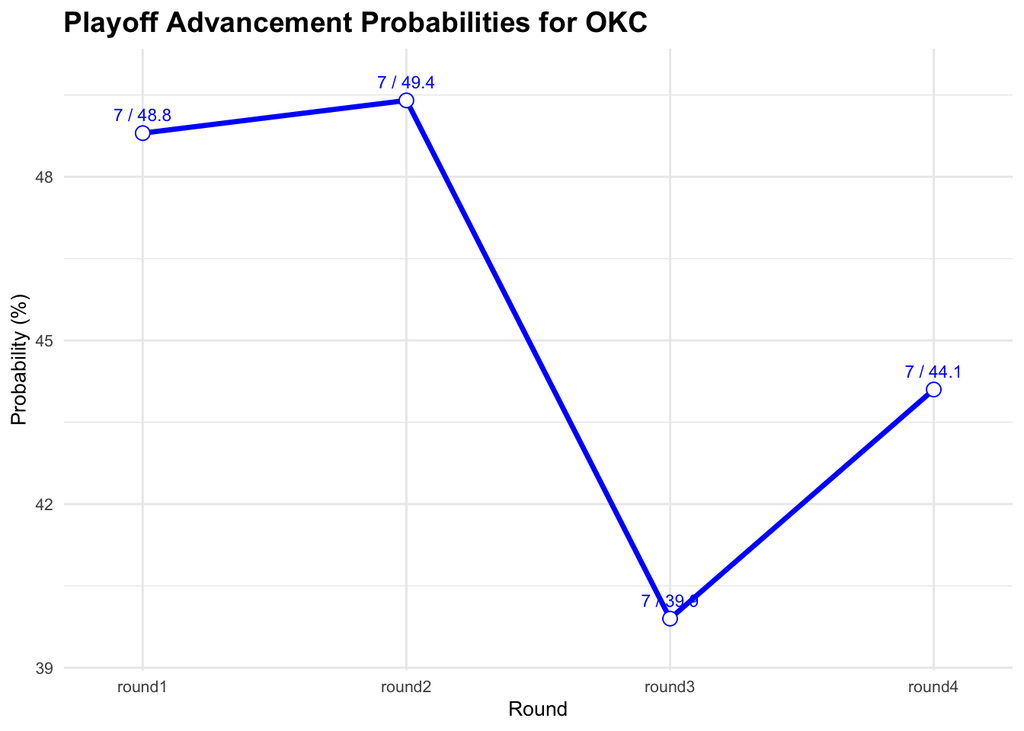

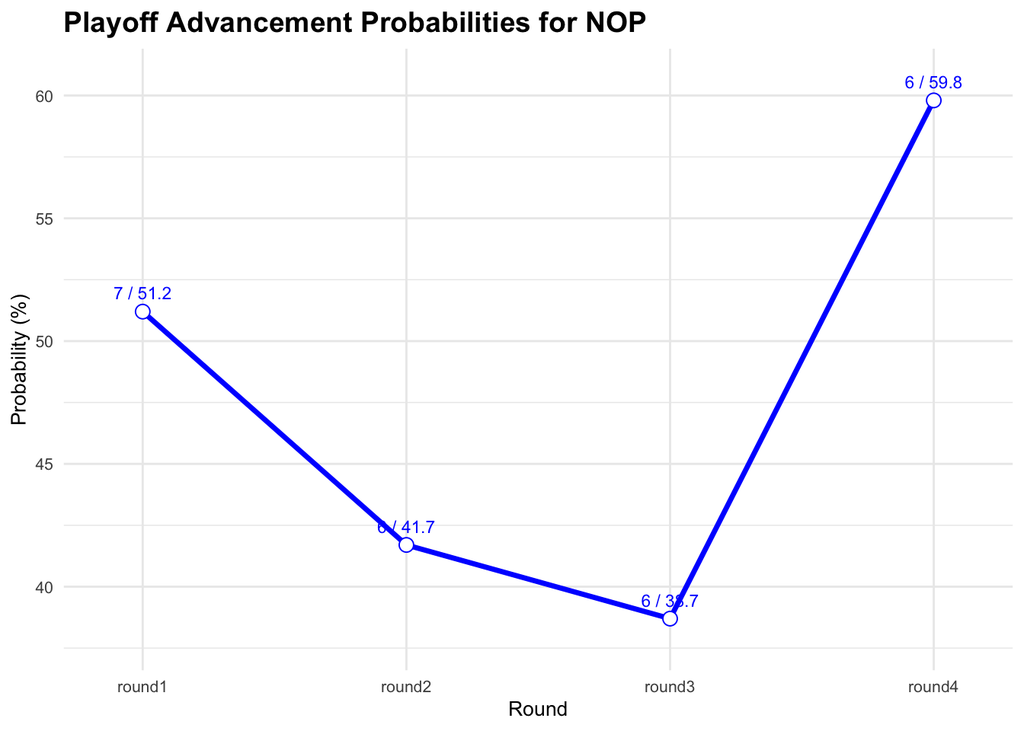

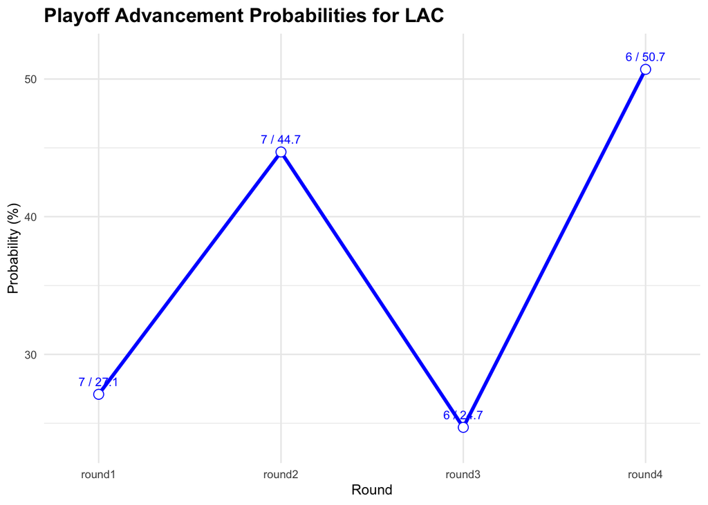

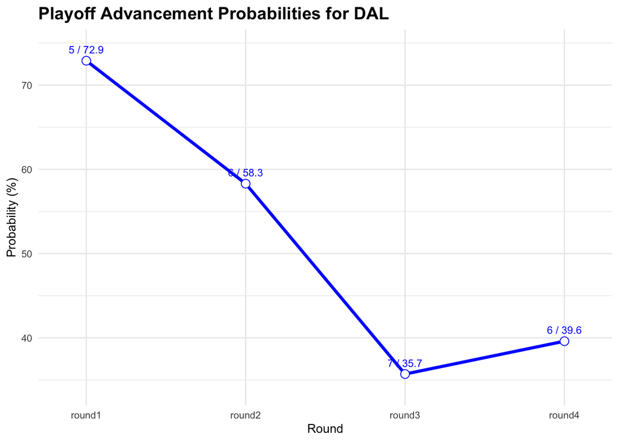

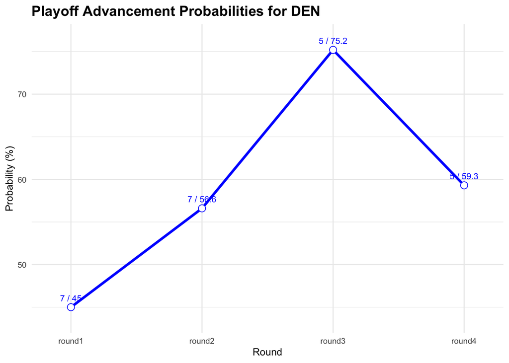

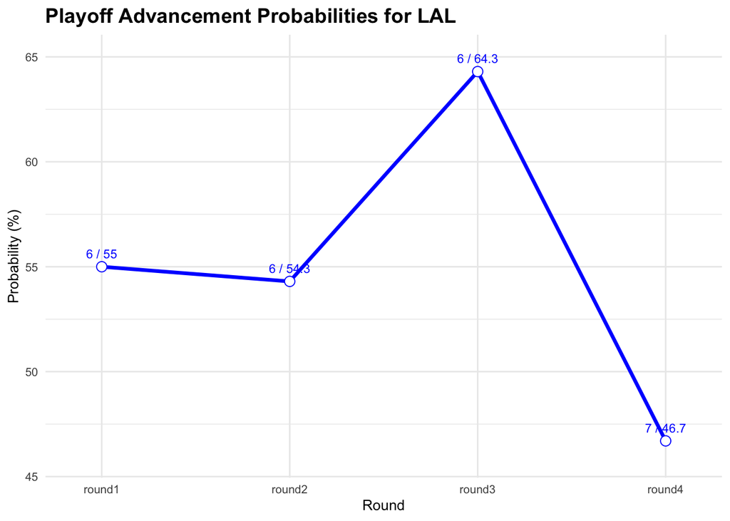

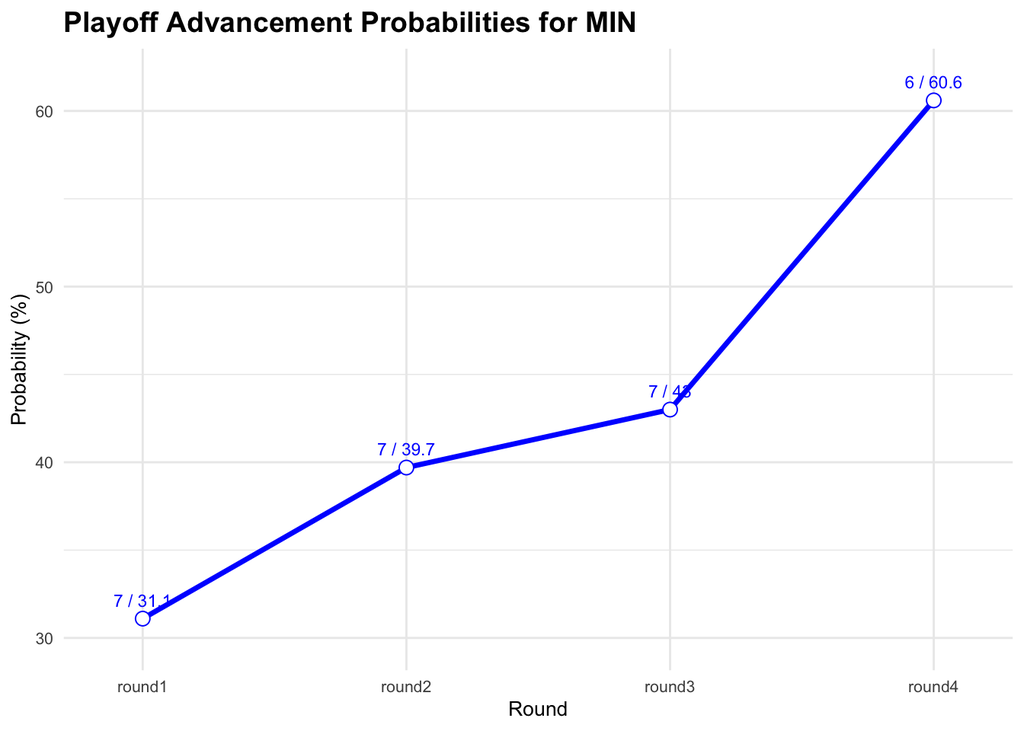

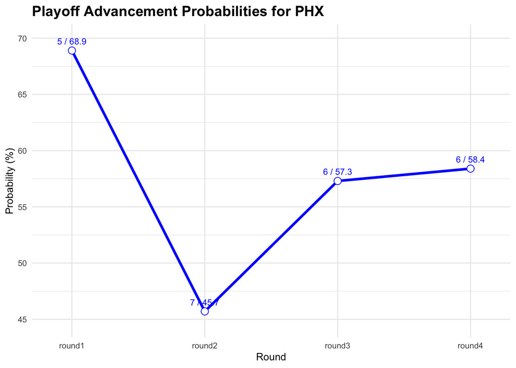

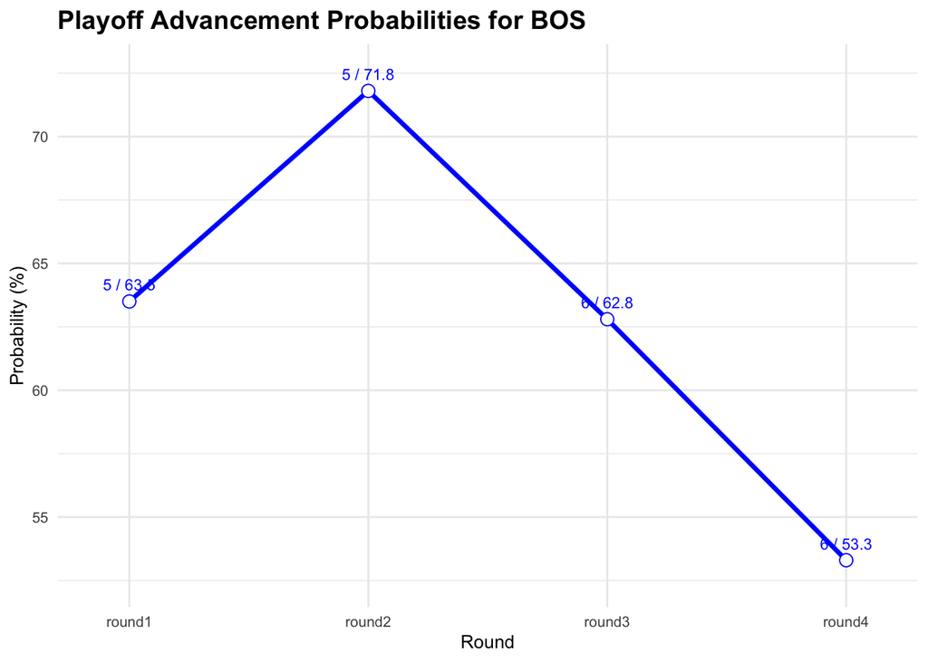

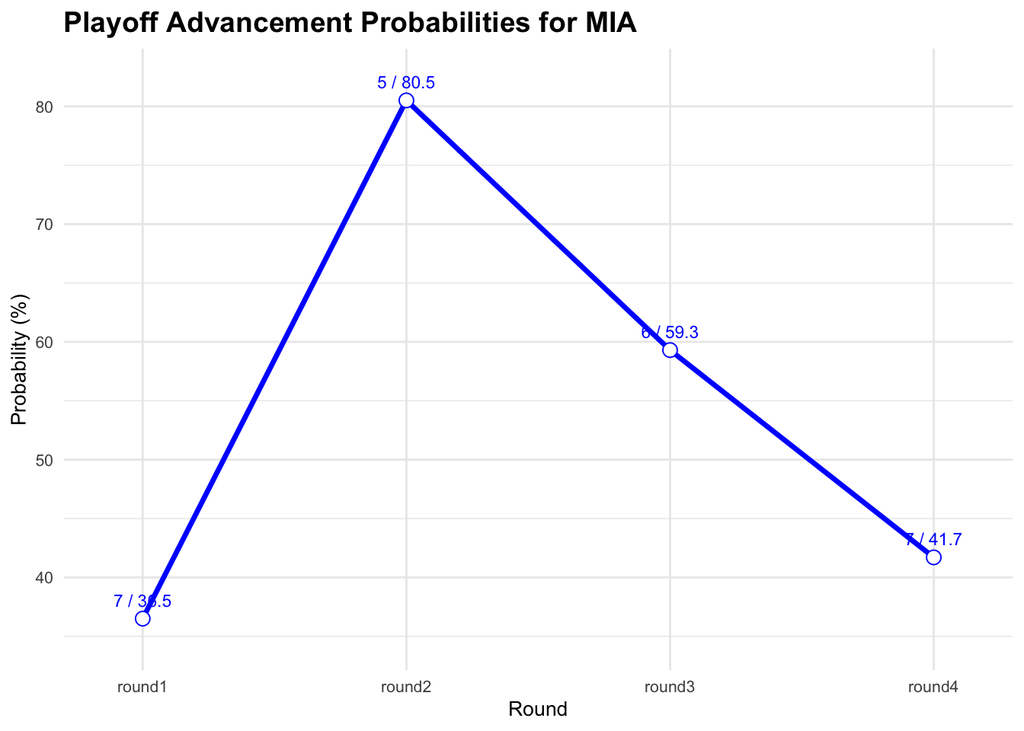

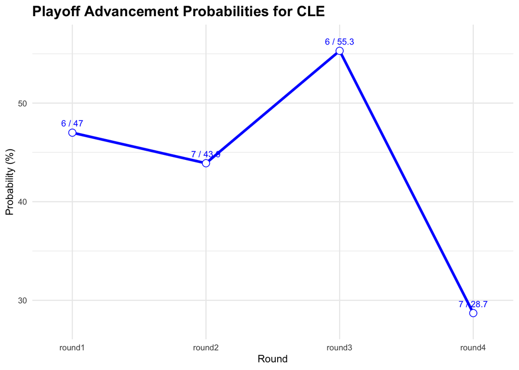

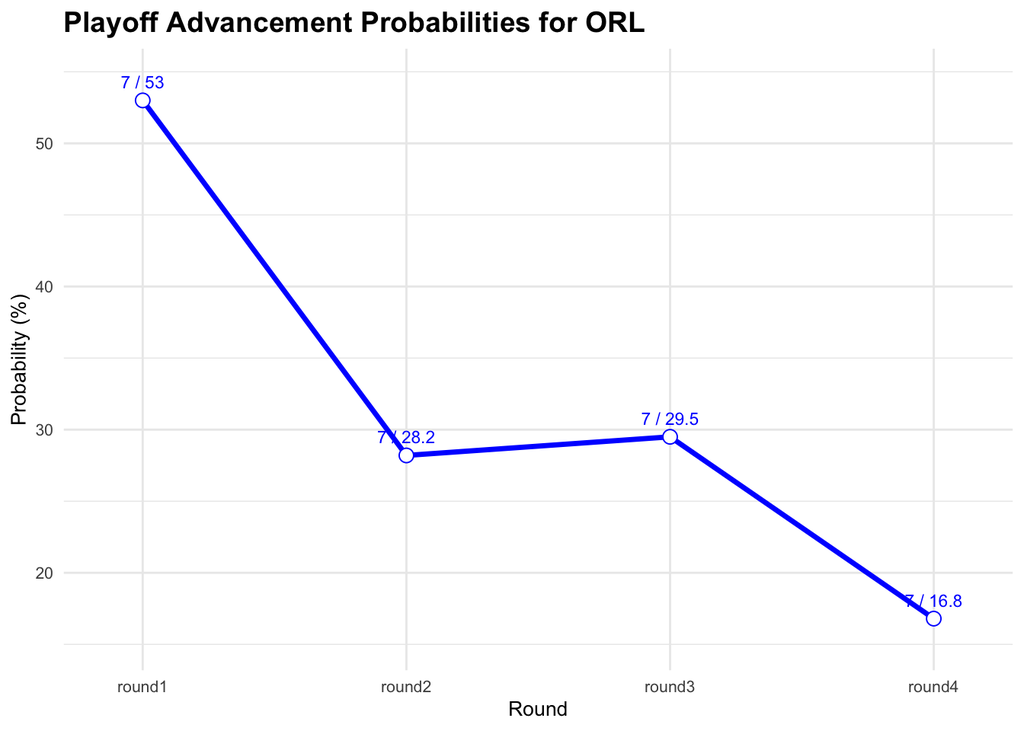

[4 more figures not shown]

```r
teams <- c("OKC", "NOP", "LAC", "DAL", "DEN", "LAL", "MIN", "PHX", "BOS", "MIA", "CLE", "ORL", "NYK", "PHI", "MIL", "IND")
rounds <- c("round1", "round2", "round3", "round4")
for (team_name in teams) {
  team_data <- data %>% filter(team == team_name)

  p <- ggplot(team_data, aes(x = round, y = probability, group = team)) +
    geom_line(size = 1.2, color = "blue") +
    geom_point(size = 3, shape = 21, fill = "white", color = "blue") +
    geom_text(aes(label = paste(num_games, "/", round(probability, 1))), vjust = -1, size = 3, color = "blue") +
    labs(title = paste("Playoff Advancement Probabilities for", team_name),
         x = "Round",
         y = "Probability (%)") +
    theme_minimal() +
    theme(
      plot.title = element_text(size = 14, face = "bold"),
      axis.title = element_text(size = 10),
      axis.text = element_text(size = 8),
      legend.position = "none"
    ) +
    scale_x_discrete(expand = expansion(mult = c(0.1, 0.1))) +
    scale_y_continuous(expand = expansion(mult = c(0.1, 0.1)))

  print(p)
}
```

## Part 3 – Finding Insights from Your Model

Find two teams that had a competitive window of 2 or more consecutive seasons making the playoffs and that under performed your model’s expectations for them, losing series they were expected to win. Why do you think that happened? Classify one of them as bad luck and one of them as relating to a cause not currently accounted for in your model. If given more time and data, how would you use what you found to improve your model?

```r
team_data <- read_csv("team_game_data.csv")
head(team_data)
```

```
## # A tibble: 6 × 41
##   season gametype nbagameid gamedate   offensivenbateamid off_team_name off_team
##    <dbl>    <dbl>     <dbl> <date>                  <dbl> <chr>         <chr>
## 1   2016        2  21600495 2016-12-30         1610612740 New Orleans … NOP
## 2   2016        2  21600495 2016-12-30         1610612752 New York Kni… NYK
## 3   2021        2  22100943 2022-03-03         1610612742 Dallas Maver… DAL
## 4   2021        2  22100943 2022-03-03         1610612744 Golden State… GSW
## 5   2016        2  21601032 2017-03-18         1610612741 Chicago Bulls CHI
## 6   2016        2  21601032 2017-03-18         1610612762 Utah Jazz     UTA
## # ℹ 34 more variables: off_home <dbl>, off_win <dbl>, defensivenbateamid <dbl>,
## #   def_team_name <chr>, def_team <chr>, def_home <dbl>, def_win <dbl>,
## #   fg2made <dbl>, fg2missed <dbl>, fg2attempted <dbl>, fg3made <dbl>,
## #   fg3missed <dbl>, fg3attempted <dbl>, fgmade <dbl>, fgmissed <dbl>,
## #   fgattempted <dbl>, ftmade <dbl>, ftmissed <dbl>, ftattempted <dbl>,
## #   reboffensive <dbl>, rebdefensive <dbl>, reboundchance <dbl>, assists <dbl>,
## #   stealsagainst <dbl>, turnovers <dbl>, blocksagainst <dbl>, …
```

```r
# Filter playoff teams for the 2022 season
playoff_teams_2022 <- team_data %>%
  filter(gametype == 4 & season == 2022) %>%
  select(season, off_team) %>%
  distinct()

# CLE and MIN

print(playoff_teams_2022)
```

```
## # A tibble: 16 × 2
##    season off_team
##     <dbl> <chr>
##  1   2022 MIA
##  2   2022 DEN
##  3   2022 NYK
##  4   2022 BOS
##  5   2022 PHX
##  6   2022 CLE
##  7   2022 SAC
##  8   2022 GSW
##  9   2022 ATL
## 10   2022 LAL
## 11   2022 PHI
## 12   2022 LAC
## 13   2022 MEM
## 14   2022 MIN
## 15   2022 BKN
## 16   2022 MIL
```

```r
# Filter regular season data for the 2023 season
regular_season_2023 <- team_data %>%
  filter(gametype == 2 & season == 2023)

# Calculate the regular season records for CLE and MIN
team_records <- regular_season_2023 %>%
  filter(off_team %in% c("CLE", "MIN")) %>%
  group_by(off_team) %>%
  summarise(
    wins = sum(off_win),
    losses = n() - sum(off_win)
  )
print(team_records)
```

```
## # A tibble: 2 × 3
##   off_team  wins losses
##   <chr>    <dbl>  <dbl>
## 1 CLE         48     34
## 2 MIN         56     26
```

```r
print(latest_data_filter)
```

```
## # A tibble: 16 × 32
##    off_team off_home opponentteampoints offensiveseconds defensiveseconds
##    <chr>    <fct>                 <dbl>            <dbl>            <dbl>
##  1 BOS      1                      82.6            1083.            1070
##  2 CLE      1                      86.6            1062.            1118.
##  3 DAL      1                      82.1            1133.            1132.
##  4 DEN      0                      81.8            1076.            1107.
##  5 IND      0                      86.2             983.            1076.
##  6 LAC      1                      86              1139.            1119.
##  7 LAL      0                      93.3            1172.            1157.
##  8 MIA      1                      80.3            1117.            1118.
##  9 MIL      0                      88.7            1138.            1124.
## 10 MIN      1                      80.1            1103.            1064
## 11 NOP      0                      95              1206.            1245.
## 12 NYK      1                     103.             1378.            1230.
## 13 OKC      1                      79.5             962.            1042.
## 14 ORL      0                      84.1            1090.            1079.
## 15 PHI      1                      89              1179.            1178.
## 16 PHX      0                      86.2            1171.            1118.
## # ℹ 27 more variables: assists.x <dbl>, rebdefensive.x <dbl>,
## #   stealsagainst.x <dbl>, defensivefoulsdrawn <dbl>, off_win <dbl>,
## #   shotattemptpoints.x <dbl>, fg2missed.x <dbl>,
## #   opponentteamfg3attempted <dbl>, fg3missed.y <dbl>, fg3made.y <dbl>,
## #   shotattemptpoints.y <dbl>, points.y <dbl>, steals <dbl>, ftmissed.y <dbl>,
## #   turnovers.x <dbl>, defensivefouls.x <dbl>, points.x <dbl>,
## #   possessions <dbl>, blocksagainst.x <dbl>, offensivefouls.x <dbl>, …
```

```r
# Calculate the average values for all columns except off_team and off_home
mean_values <- latest_data_filter %>%
  select(-off_team, -off_home) %>%
  summarise_all(mean, na.rm = TRUE)

filtered_data <- latest_data_filter %>%
  filter(off_team %in% c("CLE", "MIN"))

# Calculate the difference from the average values
comparison <- filtered_data %>%
  mutate(across(-c(off_team, off_home), ~ . - mean_values[[cur_column()]])) %>%
  select(off_team, everything(), -off_home)

print(comparison)
```

```
## # A tibble: 2 × 31
##   off_team opponentteampoints offensiveseconds defensiveseconds assists.x
##   <chr>                 <dbl>            <dbl>            <dbl>     <dbl>
## 1 CLE                  0.0812            -62.7            -5.28     3.1
## 2 MIN                 -6.42              -21.8           -59.6      0.900
## # ℹ 26 more variables: rebdefensive.x <dbl>, stealsagainst.x <dbl>,
## #   defensivefoulsdrawn <dbl>, off_win <dbl>, shotattemptpoints.x <dbl>,
## #   fg2missed.x <dbl>, opponentteamfg3attempted <dbl>, fg3missed.y <dbl>,
## #   fg3made.y <dbl>, shotattemptpoints.y <dbl>, points.y <dbl>, steals <dbl>,
## #   ftmissed.y <dbl>, turnovers.x <dbl>, defensivefouls.x <dbl>,
## #   points.x <dbl>, possessions <dbl>, blocksagainst.x <dbl>,
## #   offensivefouls.x <dbl>, shootingfoulsdrawn.x <dbl>, blocks <dbl>, …
```

```r
# Get the latest 10 records for MIN
latest_min_data <- team_data %>%
  filter(off_team == "MIN") %>%
  arrange(desc(gamedate)) %>%
  head(10)

print(latest_min_data)
```

```
## # A tibble: 10 × 41
##    season gametype nbagameid gamedate   offensivenbateamid off_team_name
##     <dbl>    <dbl>     <dbl> <date>                  <dbl> <chr>
##  1   2023        2  22301194 2024-04-14         1610612750 Minnesota Timberwolv…
##  2   2023        2  22301178 2024-04-12         1610612750 Minnesota Timberwolv…
##  3   2023        2  22301164 2024-04-10         1610612750 Minnesota Timberwolv…
##  4   2023        2  22301152 2024-04-09         1610612750 Minnesota Timberwolv…
##  5   2023        2  22301143 2024-04-07         1610612750 Minnesota Timberwolv…
##  6   2023        2  22301125 2024-04-05         1610612750 Minnesota Timberwolv…
##  7   2023        2  22301108 2024-04-03         1610612750 Minnesota Timberwolv…
##  8   2023        2  22301098 2024-04-02         1610612750 Minnesota Timberwolv…
##  9   2023        2  22301084 2024-03-31         1610612750 Minnesota Timberwolv…
## 10   2023        2  22301071 2024-03-29         1610612750 Minnesota Timberwolv…
## # ℹ 35 more variables: off_team <chr>, off_home <dbl>, off_win <dbl>,
## #   defensivenbateamid <dbl>, def_team_name <chr>, def_team <chr>,
## #   def_home <dbl>, def_win <dbl>, fg2made <dbl>, fg2missed <dbl>,
## #   fg2attempted <dbl>, fg3made <dbl>, fg3missed <dbl>, fg3attempted <dbl>,
## #   fgmade <dbl>, fgmissed <dbl>, fgattempted <dbl>, ftmade <dbl>,
## #   ftmissed <dbl>, ftattempted <dbl>, reboffensive <dbl>, rebdefensive <dbl>,
## #   reboundchance <dbl>, assists <dbl>, stealsagainst <dbl>, turnovers <dbl>, …
```

### Minnesota Timberwolves (MIN) – Model Deficiency

The Minnesota Timberwolves, with only a 31.1% probability of winning the first round and around a 40% likelihood in the second round and semifinals, suggest potential gaps in the model. Despite their lower probabilities, MIN’s actual performance in the playoffs may have been influenced by trends not captured by the current model.

Both teams, CLE and MIN, exhibited offensiveseconds and rebdefensive values below the average of the 16 playoff teams. This could be attributed to the model’s reliance on a rolling window size of 10 games, which may not adequately capture longer-term trends for certain variables. Extending the time window could provide a more comprehensive view of team performance. Specifically for MIN, this deficiency indicates that their playoff performance may not be accurately reflected due to short-term fluctuations in their data. Moreover, the disparity in offensiveseconds and rebdefensive suggests that MIN may have had structural or strategic changes during the playoffs that the model did not account for.

### Model Improvement Strategies

To enhance the robustness of the model, several approaches can be taken:

Extended Time Window: Implementing a longer time window for variables like offensiveseconds and rebdefensive.x to capture more comprehensive trends. Multiple Models: Building and comparing multiple models using different methodologies to ensure robustness and reduce reliance on a single variable set. Player Data Representation: Instead of using the maximum value to summarize player data, exploring other statistical representations, such as mean or weighted averages, to better reflect player contributions and team dynamics. Incorporating Additional Factors: Including other potentially influential factors, such as injuries, player rotations, and coaching strategies, to refine predictions. By addressing these areas, the model can be improved to provide more accurate and reliable predictions for future playoff outcomes.